# Identify_Customer_Segments

### Prerequsite - Upgrade Scikit Learn

The current workspace has scikit-learn v0.19.1 installed. However, you can upgrade scikit-learn to 0.24.x. and use this [OneHotEncoder](https://scikit-learn.org/0.21/modules/generated/sklearn.preprocessing.OneHotEncoder.html) library.

```python
import sklearn
print('The scikit-learn version is {}.'.format(sklearn.__version__))
#import and upgrade Pandas so I can cast NaNs to Int64.
import pandas as pd
print('The pandas version is {}.'.format(pd.__version__))
```

```
The scikit-learn version is 0.24.2.
The pandas version is 1.1.5.
```

```python
import os
os.environ['PATH'] = f"{os.environ['PATH']}:/root/.local/bin"
```

Restart the Kernel.

```python
!python -m pip install --upgrade scikit-learn
!python -m pip install --upgrade pandas
import sklearn
import pandas as pd
print('The scikit-learn version is {}.'.format(sklearn.__version__))
print('The pandas version is {}.'.format(pd.__version__))
```

```
The scikit-learn version is 0.24.2.
The pandas version is 1.1.5.
```

```python
# Now you can import and use OneHotEncoder
#from sklearn.preprocessing import OneHotEncoder
# your code goes here
#Note: importing OneHotEncoder fails and gives me "ImportError: cannot import name '_allclose_dense_sparse'"
#so if possible, I'm just going to use pd.get_dummies
```

```python
# Similarly, should you need any other package, they can install it as:
#!python -m pip install 'tensorflow-tensorboard<0.2.0,>=0.1.0'
```

# Project: Identify Customer Segments

In this project, you will apply unsupervised learning techniques to identify segments of the population that form the core customer base for a mail-order sales company in Germany. These segments can then be used to direct marketing campaigns towards audiences that will have the highest expected rate of returns. The data that you will use has been provided by our partners at Bertelsmann Arvato Analytics, and represents a real-life data science task.

This notebook will help you complete this task by providing a framework within which you will perform your analysis steps. In each step of the project, you will see some text describing the subtask that you will perform, followed by one or more code cells for you to complete your work. **Feel free to add additional code and markdown cells as you go along so that you can explore everything in precise chunks.** The code cells provided in the base template will outline only the major tasks, and will usually not be enough to cover all of the minor tasks that comprise it.

It should be noted that while there will be precise guidelines on how you should handle certain tasks in the project, there will also be places where an exact specification is not provided. **There will be times in the project where you will need to make and justify your own decisions on how to treat the data.** These are places where there may not be only one way to handle the data. In real-life tasks, there may be many valid ways to approach an analysis task. One of the most important things you can do is clearly document your approach so that other scientists can understand the decisions you've made.

At the end of most sections, there will be a Markdown cell labeled **Discussion**. In these cells, you will report your findings for the completed section, as well as document the decisions that you made in your approach to each subtask. **Your project will be evaluated not just on the code used to complete the tasks outlined, but also your communication about your observations and conclusions at each stage.**

```python
# import libraries here; add more as necessary
import numpy as np
#import pandas as pd #imported above with sklearn
import matplotlib.pyplot as plt
import seaborn as sns
from matplotlib import figure
from sklearn.preprocessing import StandardScaler
from sklearn.decomposition import PCA
from sklearn.cluster import KMeans
import time #used for timing long processes

# magic word for producing visualizations in notebook
%matplotlib inline

'''
Import note: The classroom currently uses sklearn version 0.19.
If you need to use an imputer, it is available in sklearn.preprocessing.Imputer,
instead of sklearn.impute as in newer versions of sklearn.
'''
pd.options.display.max_rows = None
pd.options.display.max_columns = None
```

### Step 0: Load the Data

There are four files associated with this project (not including this one):

- `Udacity_AZDIAS_Subset.csv`: Demographics data for the general population of Germany; 891211 persons (rows) x 85 features (columns).
- `Udacity_CUSTOMERS_Subset.csv`: Demographics data for customers of a mail-order company; 191652 persons (rows) x 85 features (columns).
- `Data_Dictionary.md`: Detailed information file about the features in the provided datasets.
- `AZDIAS_Feature_Summary.csv`: Summary of feature attributes for demographics data; 85 features (rows) x 4 columns

Each row of the demographics files represents a single person, but also includes information outside of individuals, including information about their household, building, and neighborhood. You will use this information to cluster the general population into groups with similar demographic properties. Then, you will see how the people in the customers dataset fit into those created clusters. The hope here is that certain clusters are over-represented in the customers data, as compared to the general population; those over-represented clusters will be assumed to be part of the core userbase. This information can then be used for further applications, such as targeting for a marketing campaign.

To start off with, load in the demographics data for the general population into a pandas DataFrame, and do the same for the feature attributes summary. Note for all of the `.csv` data files in this project: they're semicolon (`;`) delimited, so you'll need an additional argument in your [`read_csv()`](https://pandas.pydata.org/pandas-docs/stable/generated/pandas.read_csv.html) call to read in the data properly. Also, considering the size of the main dataset, it may take some time for it to load completely.

Once the dataset is loaded, it's recommended that you take a little bit of time just browsing the general structure of the dataset and feature summary file. You'll be getting deep into the innards of the cleaning in the first major step of the project, so gaining some general familiarity can help you get your bearings.

```python
# Load in the general demographics data.
demo = pd.read_csv('Udacity_AZDIAS_Subset.csv', sep=';')
# Load in the feature summary file.
feat_info = pd.read_csv('AZDIAS_Feature_Summary.csv', sep=';')
```

```python
# Check the structure of the data after it's loaded (e.g. print the number of
# rows and columns, print the first few rows).
demo.shape
```

```
(891221, 85)
```

```python
demo.head()
```

|  | AGER_TYP | ALTERSKATEGORIE_GROB | ANREDE_KZ | CJT_GESAMTTYP | FINANZ_MINIMALIST | FINANZ_SPARER | FINANZ_VORSORGER | FINANZ_ANLEGER | FINANZ_UNAUFFAELLIGER | FINANZ_HAUSBAUER | FINANZTYP | GEBURTSJAHR | GFK_URLAUBERTYP | GREEN_AVANTGARDE | HEALTH_TYP | LP_LEBENSPHASE_FEIN | LP_LEBENSPHASE_GROB | LP_FAMILIE_FEIN | LP_FAMILIE_GROB | LP_STATUS_FEIN | LP_STATUS_GROB | NATIONALITAET_KZ | PRAEGENDE_JUGENDJAHRE | RETOURTYP_BK_S | SEMIO_SOZ | SEMIO_FAM | SEMIO_REL | SEMIO_MAT | SEMIO_VERT | … |
| --- | --- | --- | --- | --- | --- | --- | --- | --- | --- | --- | --- | --- | --- | --- | --- | --- | --- | --- | --- | --- | --- | --- | --- | --- | --- | --- | --- | --- | --- | --- |
| 0 | -1 | 2 | 1 | 2.0 | 3 | 4 | 3 | 5 | 5 | 3 | 4 | 0 | 10.0 | 0 | -1 | 15.0 | 4.0 | 2.0 | 2.0 | 1.0 | 1.0 | 0 | 0 | 5.0 | 2 | 6 | 7 | 5 | 1 | … |
| 1 | -1 | 1 | 2 | 5.0 | 1 | 5 | 2 | 5 | 4 | 5 | 1 | 1996 | 10.0 | 0 | 3 | 21.0 | 6.0 | 5.0 | 3.0 | 2.0 | 1.0 | 1 | 14 | 1.0 | 5 | 4 | 4 | 3 | 1 | … |
| 2 | -1 | 3 | 2 | 3.0 | 1 | 4 | 1 | 2 | 3 | 5 | 1 | 1979 | 10.0 | 1 | 3 | 3.0 | 1.0 | 1.0 | 1.0 | 3.0 | 2.0 | 1 | 15 | 3.0 | 4 | 1 | 3 | 3 | 4 | … |
| 3 | 2 | 4 | 2 | 2.0 | 4 | 2 | 5 | 2 | 1 | 2 | 6 | 1957 | 1.0 | 0 | 2 | 0.0 | 0.0 | 0.0 | 0.0 | 9.0 | 4.0 | 1 | 8 | 2.0 | 5 | 1 | 2 | 1 | 4 | … |
| 4 | -1 | 3 | 1 | 5.0 | 4 | 3 | 4 | 1 | 3 | 2 | 5 | 1963 | 5.0 | 0 | 3 | 32.0 | 10.0 | 10.0 | 5.0 | 3.0 | 2.0 | 1 | 8 | 5.0 | 6 | 4 | 4 | 2 | 7 | … |

```python
feat_info.shape
```

```
(85, 4)
```

```python
feat_info.head()
```

|  | attribute | information_level | type | missing_or_unknown |
| --- | --- | --- | --- | --- |
| 0 | AGER_TYP | person | categorical | [-1,0] |
| 1 | ALTERSKATEGORIE_GROB | person | ordinal | [-1,0,9] |
| 2 | ANREDE_KZ | person | categorical | [-1,0] |
| 3 | CJT_GESAMTTYP | person | categorical | [0] |
| 4 | FINANZ_MINIMALIST | person | ordinal | [-1] |

> **Tip**: Add additional cells to keep everything in reasonably-sized chunks! Keyboard shortcut `esc --> a` (press escape to enter command mode, then press the 'A' key) adds a new cell before the active cell, and `esc --> b` adds a new cell after the active cell. If you need to convert an active cell to a markdown cell, use `esc --> m` and to convert to a code cell, use `esc --> y`.

## Step 1: Preprocessing

### Step 1.1: Assess Missing Data

The feature summary file contains a summary of properties for each demographics data column. You will use this file to help you make cleaning decisions during this stage of the project. First of all, you should assess the demographics data in terms of missing data. Pay attention to the following points as you perform your analysis, and take notes on what you observe. Make sure that you fill in the **Discussion** cell with your findings and decisions at the end of each step that has one!

#### Step 1.1.1: Convert Missing Value Codes to NaNs

The fourth column of the feature attributes summary (loaded in above as `feat_info`) documents the codes from the data dictionary that indicate missing or unknown data. While the file encodes this as a list (e.g. `[-1,0]`), this will get read in as a string object. You'll need to do a little bit of parsing to make use of it to identify and clean the data. Convert data that matches a 'missing' or 'unknown' value code into a numpy NaN value. You might want to see how much data takes on a 'missing' or 'unknown' code, and how much data is naturally missing, as a point of interest.

**As one more reminder, you are encouraged to add additional cells to break up your analysis into manageable chunks.**

First, I want to identify the codes that indicate a cell should be null:

```python
feat_info.missing_or_unknown.unique()
```

```
array(['[-1,0]', '[-1,0,9]', '[0]', '[-1]', '[]', '[-1,9]', '[-1,X]',
       '[XX]', '[-1,XX]'], dtype=object)
```

The codes are -1, 0, 9, X, XX, and an empty cell. In past attempts, I spent some time making a dataframe and then a dictionary out of the features and their missing_or_unknown codes. My goal was to use the dictionary as a map to transform values in the demo dataframe into np.nan, column-by-column where appropriate, but I found that approach too resource intensive.  
Instead, I wondered whether I could transform the values without using a dictionary, i.e. transform every missing_or_unknown code into np.nan regardless of what column it's in. I looked through the data dictionary and found that there are no valid uses of any of the codes except for '0' and '9'. In other words, the only reason a cell would ever have -1 in it is if the value is missing or unknown, but occasionally '9' indicates something besides 'missing or unknown'.  
Since that's the case, I can safely transform every code value except 0 and 9 into a np.nan. Then, I can make a list of the columns where 0 or 9 indicates 'missing or unknown,' and transform them into np.nan in just those columns.

```python
# Step 1: Gather information about the null values and null codes for validation purposes later:
print("Total values in the dataset: {}".format(demo.shape[0] * demo.shape[1])) #total values
print("Total null values: {}".format(demo.isnull().sum().sum())) #null values
```

```
Total values in the dataset: 75753785
Total null values: 4896838
```

```python
demo.dtypes
```

```
AGER_TYP                   int64
ALTERSKATEGORIE_GROB       int64
ANREDE_KZ                  int64
CJT_GESAMTTYP            float64
FINANZ_MINIMALIST          int64
FINANZ_SPARER              int64
FINANZ_VORSORGER           int64
FINANZ_ANLEGER             int64
FINANZ_UNAUFFAELLIGER      int64
FINANZ_HAUSBAUER           int64
FINANZTYP                  int64
GEBURTSJAHR                int64
GFK_URLAUBERTYP          float64
GREEN_AVANTGARDE           int64
HEALTH_TYP                 int64
LP_LEBENSPHASE_FEIN      float64
LP_LEBENSPHASE_GROB      float64
LP_FAMILIE_FEIN          float64
LP_FAMILIE_GROB          float64
LP_STATUS_FEIN           float64
LP_STATUS_GROB           float64
NATIONALITAET_KZ           int64
PRAEGENDE_JUGENDJAHRE      int64
RETOURTYP_BK_S           float64
SEMIO_SOZ                  int64
SEMIO_FAM                  int64
SEMIO_REL                  int64
SEMIO_MAT                  int64
SEMIO_VERT                 int64
SEMIO_LUST                 int64
SEMIO_ERL                  int64
SEMIO_KULT                 int64
SEMIO_RAT                  int64
SEMIO_KRIT                 int64
SEMIO_DOM                  int64
SEMIO_KAEM                 int64
SEMIO_PFLICHT              int64
SEMIO_TRADV                int64
SHOPPER_TYP                int64
SOHO_KZ                  float64
```

[output cut: 31 more lines]

```
MOBI_REGIO               float64
ONLINE_AFFINITAET        float64
REGIOTYP                 float64
KBA13_ANZAHL_PKW         float64
PLZ8_ANTG1               float64
PLZ8_ANTG2               float64
PLZ8_ANTG3               float64
PLZ8_ANTG4               float64
PLZ8_BAUMAX              float64
PLZ8_HHZ                 float64
PLZ8_GBZ                 float64
ARBEIT                   float64
ORTSGR_KLS9              float64
RELAT_AB                 float64
dtype: object
```

```python
#counting null codes:
str_columns = ['OST_WEST_KZ', 'CAMEO_DEUG_2015', 'CAMEO_DEU_2015', 'CAMEO_INTL_2015']
"""
string-type columns use codes 'X', 'XX', or '' to denote missing or unknown values.
Numeric-type columns use -1 and 0. I will be processing string-type and numeric-type columns
separately because they can't be compared using comparison-operators.
"""
null_code_counts = 0 #This will hold the number of null/missing-coded cells
for label, content in demo.items():
    if label not in str_columns: #Count numeric-type null/missing coded cells:
        null_code_counts += len(demo[(demo[label] == -1)])
    #count string-type missing/coded cells:
    else: null_code_counts += len(demo[(demo[label] == '') | \
                            (demo[label] == 'X') | \
                            (demo[label] == 'XX')])
```

```python
null_code_counts
```

```
1012210
```

According to this count, there are 1,012,210 cells that are coded 'missing' or 'unknown' using codes -1, X, XX, and ''. After completing the transformation of everything but 0 and 9 to np.nan, this number should be 0. There should then be 1,012,210 + 4,896,838 = 5,909,048 null values.

```python
"""
#Unused code to extract the codes from 'missing_or_unknown' and turn them into a dictionary
#Make a dictionary of the 'null codes':
null_codes = feat_info.missing_or_unknown.str.extract('\[(?P<Neg1>-1)?,?(?P<Zero>0)?,?(?P<Nine>9)?,?(?P<X>X+)?', expand=True)
#null_codes = null_codes.T.to_dict('list')
"""
```

```
"\n#Unused code to extract the codes from 'missing_or_unknown' and turn them into a dictionary\n#Make a dictionary of the 'null codes': \nnull_codes = feat_info.missing_or_unknown.str.extract('\\[(?P<Neg1>-1)?,?(?P<Zero>0)?,?(?P<Nine>9)?,?(?P<X>X+)?', expand=True)\n#null_codes = null_codes.T.to_dict…
```

```python
# Transform codes to np.NaN:
for label, content in demo.items():
    if label not in str_columns: #transform numeric-type null/missing coded cells first:
        demo[label] = demo[label].apply(lambda x: np.NaN if (x == -1) else x)
    else: demo[label] = demo[label].apply(lambda x: np.NaN if ((x == '') or (x == 'X') or (x == 'XX')) else x) #transform string-type null/missing coded cells
###Note: I don't know why, but ((x == '') or (x == 'X') or (x == 'XX')) works, while (x == ('X' or 'XX' or '')) does not
```

```python
#Test transformation of '-1', '', 'X', and 'XX' codes:
print("Total values in the dataset: {}".format(demo.shape[0] * demo.shape[1])) #total values
print("Total null values: {}".format(demo.isnull().sum().sum())) #null values
```

```
Total values in the dataset: 75753785
Total null values: 5909048
```

Success! The total null value count matches the testing value I calculated above. Now to transform the 9s and 0s. First, I need to know which columns use 9 or 0 as a 'missing or unknown' code:

```python
#Take another peek at the feat_info dataframe without scrolling a lot
feat_info.head()
```

|  | attribute | information_level | type | missing_or_unknown |
| --- | --- | --- | --- | --- |
| 0 | AGER_TYP | person | categorical | [-1,0] |
| 1 | ALTERSKATEGORIE_GROB | person | ordinal | [-1,0,9] |
| 2 | ANREDE_KZ | person | categorical | [-1,0] |
| 3 | CJT_GESAMTTYP | person | categorical | [0] |
| 4 | FINANZ_MINIMALIST | person | ordinal | [-1] |

```python
#Add a column to feat_info indicating whether the missing/unknown code can be a '9'
feat_info['nine_codes'] = feat_info.missing_or_unknown.str.extract('(9)', expand=True)
feat_info[feat_info['nine_codes'] == '9'] #Look at just rows where missing/unknown can be coded '9'
```

|  | attribute | information_level | type | missing_or_unknown | nine_codes |
| --- | --- | --- | --- | --- | --- |
| 1 | ALTERSKATEGORIE_GROB | person | ordinal | [-1,0,9] | 9 |
| 24 | SEMIO_SOZ | person | ordinal | [-1,9] | 9 |
| 25 | SEMIO_FAM | person | ordinal | [-1,9] | 9 |
| 26 | SEMIO_REL | person | ordinal | [-1,9] | 9 |
| 27 | SEMIO_MAT | person | ordinal | [-1,9] | 9 |
| 28 | SEMIO_VERT | person | ordinal | [-1,9] | 9 |
| 29 | SEMIO_LUST | person | ordinal | [-1,9] | 9 |
| 30 | SEMIO_ERL | person | ordinal | [-1,9] | 9 |
| 31 | SEMIO_KULT | person | ordinal | [-1,9] | 9 |
| 32 | SEMIO_RAT | person | ordinal | [-1,9] | 9 |
| 33 | SEMIO_KRIT | person | ordinal | [-1,9] | 9 |
| 34 | SEMIO_DOM | person | ordinal | [-1,9] | 9 |
| 35 | SEMIO_KAEM | person | ordinal | [-1,9] | 9 |
| 36 | SEMIO_PFLICHT | person | ordinal | [-1,9] | 9 |
| 37 | SEMIO_TRADV | person | ordinal | [-1,9] | 9 |
| 42 | ZABEOTYP | person | categorical | [-1,9] | 9 |
| 82 | ARBEIT | community | ordinal | [-1,9] | 9 |
| 84 | RELAT_AB | community | ordinal | [-1,9] | 9 |

```python
#Add a column to feat_info indicating whether the missing/unknown code can be a '0'
feat_info['zero_codes'] = feat_info.missing_or_unknown.str.extract('(0)', expand=True)
feat_info[feat_info['zero_codes'] == '0'] #Look at just rows where missing/unknown can be coded '0'
```

|  | attribute | information_level | type | missing_or_unknown | nine_codes | zero_codes |
| --- | --- | --- | --- | --- | --- | --- |
| 0 | AGER_TYP | person | categorical | [-1,0] | NaN | 0 |
| 1 | ALTERSKATEGORIE_GROB | person | ordinal | [-1,0,9] | 9 | 0 |
| 2 | ANREDE_KZ | person | categorical | [-1,0] | NaN | 0 |
| 3 | CJT_GESAMTTYP | person | categorical | [0] | NaN | 0 |
| 11 | GEBURTSJAHR | person | numeric | [0] | NaN | 0 |
| 14 | HEALTH_TYP | person | ordinal | [-1,0] | NaN | 0 |
| 15 | LP_LEBENSPHASE_FEIN | person | mixed | [0] | NaN | 0 |
| 16 | LP_LEBENSPHASE_GROB | person | mixed | [0] | NaN | 0 |
| 17 | LP_FAMILIE_FEIN | person | categorical | [0] | NaN | 0 |
| 18 | LP_FAMILIE_GROB | person | categorical | [0] | NaN | 0 |
| 19 | LP_STATUS_FEIN | person | categorical | [0] | NaN | 0 |
| 20 | LP_STATUS_GROB | person | categorical | [0] | NaN | 0 |
| 21 | NATIONALITAET_KZ | person | categorical | [-1,0] | NaN | 0 |
| 22 | PRAEGENDE_JUGENDJAHRE | person | mixed | [-1,0] | NaN | 0 |
| 23 | RETOURTYP_BK_S | person | ordinal | [0] | NaN | 0 |
| 40 | TITEL_KZ | person | categorical | [-1,0] | NaN | 0 |
| 43 | ALTER_HH | household | interval | [0] | NaN | 0 |
| 46 | HH_EINKOMMEN_SCORE | household | ordinal | [-1,0] | NaN | 0 |
| 48 | W_KEIT_KIND_HH | household | ordinal | [-1,0] | NaN | 0 |
| 49 | WOHNDAUER_2008 | household | ordinal | [-1,0] | NaN | 0 |
| 50 | ANZ_HAUSHALTE_AKTIV | building | numeric | [0] | NaN | 0 |
| 52 | GEBAEUDETYP | building | categorical | [-1,0] | NaN | 0 |
| 54 | MIN_GEBAEUDEJAHR | building | numeric | [0] | NaN | 0 |
| 64 | KBA05_BAUMAX | microcell_rr3 | mixed | [-1,0] | NaN | 0 |
| 65 | KBA05_GBZ | microcell_rr3 | ordinal | [-1,0] | NaN | 0 |
| 70 | KKK | region_rr1 | ordinal | [-1,0] | NaN | 0 |
| 73 | REGIOTYP | region_rr1 | ordinal | [-1,0] | NaN | 0 |
| 79 | PLZ8_BAUMAX | macrocell_plz8 | mixed | [-1,0] | NaN | 0 |
| 83 | ORTSGR_KLS9 | community | ordinal | [-1,0] | NaN | 0 |

```python
#Look at the data types of these columns:
#First, make a list of relevant columns:
nine_code_list = feat_info[feat_info['nine_codes'] == '9'].attribute.tolist()
nine_code_list
```

```
['ALTERSKATEGORIE_GROB',
 'SEMIO_SOZ',
 'SEMIO_FAM',
 'SEMIO_REL',
 'SEMIO_MAT',
 'SEMIO_VERT',
 'SEMIO_LUST',
 'SEMIO_ERL',
 'SEMIO_KULT',
 'SEMIO_RAT',
 'SEMIO_KRIT',
 'SEMIO_DOM',
 'SEMIO_KAEM',
 'SEMIO_PFLICHT',
 'SEMIO_TRADV',
 'ZABEOTYP',
 'ARBEIT',
 'RELAT_AB']
```

```python
#Now look at their data types:
for label, content in demo.items():
    if label in nine_code_list:
        print('{0}: {1}'.format(label, demo[label].dtype))
```

```
ALTERSKATEGORIE_GROB: int64
SEMIO_SOZ: int64
SEMIO_FAM: int64
SEMIO_REL: int64
SEMIO_MAT: int64
SEMIO_VERT: int64
SEMIO_LUST: int64
SEMIO_ERL: int64
SEMIO_KULT: int64
SEMIO_RAT: int64
SEMIO_KRIT: int64
SEMIO_DOM: int64
SEMIO_KAEM: int64
SEMIO_PFLICHT: int64
SEMIO_TRADV: int64
ZABEOTYP: int64
ARBEIT: float64
RELAT_AB: float64
```

```python
#Do the same for 0 codes
zero_code_list = feat_info[feat_info['zero_codes'] == '0'].attribute.tolist() #First, make a list of relevant columns:
for label, content in demo.items():
    if label in zero_code_list:
        print('{0}: {1}'.format(label, demo[label].dtype))
```

```
AGER_TYP: float64
ALTERSKATEGORIE_GROB: int64
ANREDE_KZ: int64
CJT_GESAMTTYP: float64
GEBURTSJAHR: int64
HEALTH_TYP: float64
LP_LEBENSPHASE_FEIN: float64
LP_LEBENSPHASE_GROB: float64
LP_FAMILIE_FEIN: float64
LP_FAMILIE_GROB: float64
LP_STATUS_FEIN: float64
LP_STATUS_GROB: float64
NATIONALITAET_KZ: int64
PRAEGENDE_JUGENDJAHRE: int64
RETOURTYP_BK_S: float64
TITEL_KZ: float64
ALTER_HH: float64
HH_EINKOMMEN_SCORE: float64
W_KEIT_KIND_HH: float64
WOHNDAUER_2008: float64
ANZ_HAUSHALTE_AKTIV: float64
GEBAEUDETYP: float64
MIN_GEBAEUDEJAHR: float64
KBA05_BAUMAX: float64
KBA05_GBZ: float64
KKK: float64
REGIOTYP: float64
PLZ8_BAUMAX: float64
ORTSGR_KLS9: float64
```

Columns using a '9' or '0' as a missing/unknown code are all numeric data types, so I should be able to transform all of these values in one block. First, I'll count the values that need to change:

```python
#count 9-codes that must change:
null_code_counts = 0 #This will hold the number of null/missing-coded cells
for label, content in demo.items():
    if label in nine_code_list:
        null_code_counts += len(demo[(demo[label] == 9)])
    if label in zero_code_list:
        null_code_counts += len(demo[(demo[label] == 0)])
null_code_counts
```

```
2464881
```

There are 2,464,881 '9' and '0' codes that need to be changed to 'null.' After this operation, that number should be 0, and there should be 5,909,048 + 2,464,881 = 8,373,929 null values.

```python
#Transform 9 and 0 codes to np.NaN:
for label, content in demo.items():
    if label in nine_code_list:
        demo[label] = demo[label].apply(lambda x: np.NaN if (x == 9) else x)
    if label in zero_code_list:
        demo[label] = demo[label].apply(lambda x: np.NaN if (x == 0) else x)
```

```python
#Test: count null values:
print("Total values in the dataset: {}".format(demo.shape[0] * demo.shape[1])) #total values
print("Total null values: {}".format(demo.isnull().sum().sum())) #null values
```

```
Total values in the dataset: 75753785
Total null values: 8373929
```

That looks right to me. I have now changed all of the cells to np.NaN where a code indicated the value was missing or unknown.

#### Step 1.1.2: Assess Missing Data in Each Column

How much missing data is present in each column? There are a few columns that are outliers in terms of the proportion of values that are missing. You will want to use matplotlib's [`hist()`](https://matplotlib.org/api/_as_gen/matplotlib.pyplot.hist.html) function to visualize the distribution of missing value counts to find these columns. Identify and document these columns. While some of these columns might have justifications for keeping or re-encoding the data, for this project you should just remove them from the dataframe. (Feel free to make remarks about these outlier columns in the discussion, however!)

For the remaining features, are there any patterns in which columns have, or share, missing data?

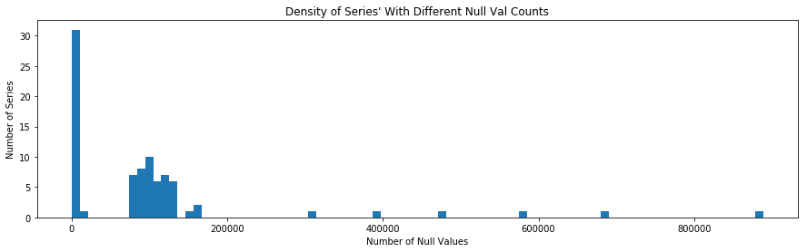

```python
# Perform an assessment of how much missing data there is in each column of the
# dataset.
#Histogram of null vals:
null_cols = demo.isnull().sum()
plt.figure(figsize=(15, 4))
plt.hist(null_cols, bins=85)
plt.xlabel('Number of Null Values')
plt.ylabel('Number of Series')
plt.title('Density of Series\' With Different Null Val Counts')

plt.show();
```

There is a large spread in how many null values are in each column. Most columns have around 100,000 or fewer null values. One has more than 800,000, and there are 5 or so spread out between those extremes.  
I'm going to discard columns where more than 1/5 of the values are null. That number (1/5) is kind of arbitrary.

```python
#That means I'm going to discard...
len(demo.AGER_TYP)/5
#... any column with more than 178,244 null values.
```

```
178244.2
```

```python
# Investigate patterns in the amount of missing data in each column.
null_spread = demo.isnull().sum()
null_spread[null_spread > 178244] #List of columns with more than 178,244 null values:
```

```
AGER_TYP        685843
GEBURTSJAHR     392318
TITEL_KZ        889061
ALTER_HH        310267
KK_KUNDENTYP    584612
KBA05_BAUMAX    476524
dtype: int64
```

```python
# Remove the outlier columns from the dataset. (You'll perform other data
# engineering tasks such as re-encoding and imputation later.)
demo.drop(columns=['AGER_TYP', 'GEBURTSJAHR', 'TITEL_KZ', 'ALTER_HH', 'KK_KUNDENTYP', 'KBA05_BAUMAX'], axis=1, inplace=True)
```

```python
#Check that columns were dropped:
demo.shape
```

```
(891221, 79)
```

#### Step 1.1.3: Assess Missing Data in Each Row

Now, you'll perform a similar assessment for the rows of the dataset. How much data is missing in each row? As with the columns, you should see some groups of points that have a very different numbers of missing values. Divide the data into two subsets: one for data points that are above some threshold for missing values, and a second subset for points below that threshold.

In order to know what to do with the outlier rows, we should see if the distribution of data values on columns that are not missing data (or are missing very little data) are similar or different between the two groups. Select at least five of these columns and compare the distribution of values.

- You can use seaborn's [`countplot()`](https://seaborn.pydata.org/generated/seaborn.countplot.html) function to create a bar chart of code frequencies and matplotlib's [`subplot()`](https://matplotlib.org/api/_as_gen/matplotlib.pyplot.subplot.html) function to put bar charts for the two subplots side by side.
- To reduce repeated code, you might want to write a function that can perform this comparison, taking as one of its arguments a column to be compared.

Depending on what you observe in your comparison, this will have implications on how you approach your conclusions later in the analysis. If the distributions of non-missing features look similar between the data with many missing values and the data with few or no missing values, then we could argue that simply dropping those points from the analysis won't present a major issue. On the other hand, if the data with many missing values looks very different from the data with few or no missing values, then we should make a note on those data as special. We'll revisit these data later on. **Either way, you should continue your analysis for now using just the subset of the data with few or no missing values.**

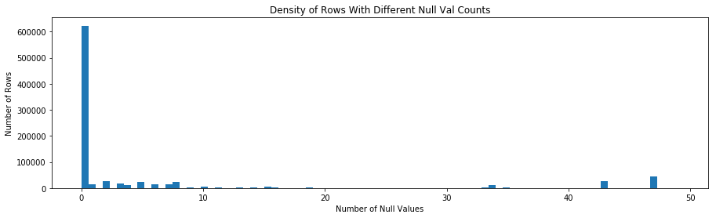

```python
# How much data is missing in each row of the dataset?
null_rows = demo.isnull().sum(axis=1)
plt.figure(figsize=(15, 4))
plt.hist(null_rows, bins=85)
plt.xlabel('Number of Null Values')
plt.ylabel('Number of Rows')
plt.title('Density of Rows With Different Null Val Counts')

plt.show();
```

Most rows have no null values, while couple have just under 50. If we remove rows with even one null value, we'll still have a very sizeable dataset, so I'm going to try that.

```python
# Write code to divide the data into two subsets based on the number of missing
# values in each row.
#For testing purposes, I'm going to get the length of the current demo dataset:

#drop duplicates preemptively so that some of the following code can be tested:
demo.drop_duplicates(inplace=True)

print('Current demo length: {}'.format(demo.shape[0]))
demo_no_null = demo.dropna(how='any',axis=0) #remove all rows with any null value
print('demo_no_null length: {}'.format(demo_no_null.shape[0])) #Get the length of the demo_no_null
"""
There is probably a better way to get the opposite dataframe (the one with null values) than this,
but I'm going to do it by appending demo_no_null to demo and then deleting duplicates,
which will leave only rows with a null value
"""
#append rows without null values to demo, making every row without a null value into a duplicate
demo_yes_null = demo.append(demo_no_null)
demo_yes_null.drop_duplicates(keep=False, inplace=True) #drop duplicates
#get the length of demo_yes-null for testing purposes.
print('demo_yes_null length: {}'.format(demo_yes_null.shape[0]))
```

```
Current demo length: 838670
demo_no_null length: 623032
demo_yes_null length: 215638
```

My first attempt at this created these values:

- Current demo length: 891221
- demo_no_null length: 623209
- demo_yes_null length: 211865  
  211,865 + 623,209 = 835,074. Because the two new dataframes don't add up to the original demo dataframe, I know something went wrong. Since there are fewer rows between the two new dataframes, maybe there were already duplicate values in the original dataframe that were also removed when I dropped dupliates. Let me try this again, but drop duplicates first.

Second attempt (dropping demo duplicates first):

- Current demo length: 838670
- demo_no_null length: 623032
- demo_yes_null length: 215638

623,032 + 215,638 = 838,670. These numbers match up, which corroborates my theory that there were already duplicates in the dataset.

```python
# Compare the distribution of values for at least five columns where there are
# no or few missing values, between the two subsets.
#Start by getting a new list of some columns:
demo.head(1)
```

|  | ALTERSKATEGORIE_GROB | ANREDE_KZ | CJT_GESAMTTYP | FINANZ_MINIMALIST | FINANZ_SPARER | FINANZ_VORSORGER | FINANZ_ANLEGER | FINANZ_UNAUFFAELLIGER | FINANZ_HAUSBAUER | FINANZTYP | GFK_URLAUBERTYP | GREEN_AVANTGARDE | HEALTH_TYP | LP_LEBENSPHASE_FEIN | LP_LEBENSPHASE_GROB | LP_FAMILIE_FEIN | LP_FAMILIE_GROB | LP_STATUS_FEIN | LP_STATUS_GROB | NATIONALITAET_KZ | PRAEGENDE_JUGENDJAHRE | RETOURTYP_BK_S | SEMIO_SOZ | SEMIO_FAM | SEMIO_REL | SEMIO_MAT | SEMIO_VERT | SEMIO_LUST | SEMIO_ERL | … |
| --- | --- | --- | --- | --- | --- | --- | --- | --- | --- | --- | --- | --- | --- | --- | --- | --- | --- | --- | --- | --- | --- | --- | --- | --- | --- | --- | --- | --- | --- | --- |
| 0 | 2.0 | 1 | 2.0 | 3 | 4 | 3 | 5 | 5 | 3 | 4 | 10.0 | 0 | NaN | 15.0 | 4.0 | 2.0 | 2.0 | 1.0 | 1.0 | NaN | NaN | 5.0 | 2 | 6 | 7 | 5 | 1 | 5 | 3 | … |

```python
#Additional helpful resource: https://www.statology.org/seaborn-subplots/
def compare_series(column):
    """
    This function takes one argument: the feature you wish to compare. It returns side-by-side
    plots of the density of values making up that column. The left plot shows the values in the
    dataframe that DOESN'T have null values (the default), and the right plot shows the values in
    the dataframe that DOES have null values.
    """
    sns.set()
    fig, axes = plt.subplots(1, 2)
    fig.suptitle('Comparison of Features')
    plt.subplots_adjust(left=None, bottom=None, right=None, top=0.8, wspace=0.5, hspace=None)
    axes[0].set_title("Without Nulls")
    sns.countplot(data=demo_no_null, x=column, ax=axes[0])
    axes[1].set_title("With Nulls")
    sns.countplot(data=demo_yes_null, x=column, ax=axes[1])
```

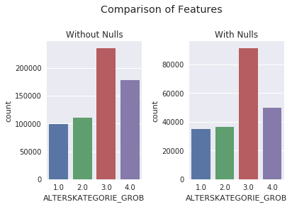

```python
#I'm going to pick five features semi-randomly:
compare_series('ALTERSKATEGORIE_GROB')
```

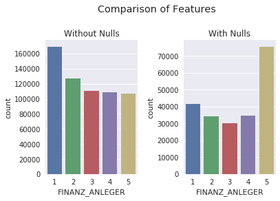

```python
compare_series('FINANZ_ANLEGER')
```

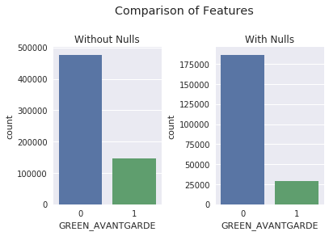

```python
compare_series('GREEN_AVANTGARDE')
```

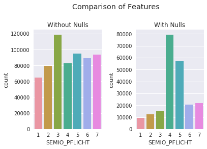

```python
compare_series('SEMIO_PFLICHT')
```

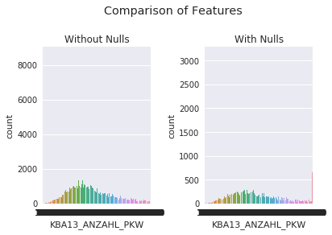

```python
compare_series('KBA13_ANZAHL_PKW')
```

```python
demo = demo_no_null.copy()
```

#### Discussion 1.1.3: Assess Missing Data in Each Row

The dataset with lots of missing values is definitely different than the dataset with no missing values. This is clear in each of the graphs above. It's not always clear whether the difference is statistically significant; the 'ALTERSKATEGORIE_GROB' and 'GREEN_AVANTGARDE' columns are very similar in both datasets. In other cases, however, the differences are pronounced; the 'FINANZ_ANLEGER' column and 'SEMIO_PFLICHT' column have striking differences that would likely affect conclusions drawn based on those features.

### Step 1.2: Select and Re-Encode Features

Checking for missing data isn't the only way in which you can prepare a dataset for analysis. Since the unsupervised learning techniques to be used will only work on data that is encoded numerically, you need to make a few encoding changes or additional assumptions to be able to make progress. In addition, while almost all of the values in the dataset are encoded using numbers, not all of them represent numeric values. Check the third column of the feature summary (`feat_info`) for a summary of types of measurement.

- For numeric and interval data, these features can be kept without changes.
- Most of the variables in the dataset are ordinal in nature. While ordinal values may technically be non-linear in spacing, make the simplifying assumption that the ordinal variables can be treated as being interval in nature (that is, kept without any changes).
- Special handling may be necessary for the remaining two variable types: categorical, and 'mixed'.

In the first two parts of this sub-step, you will perform an investigation of the categorical and mixed-type features and make a decision on each of them, whether you will keep, drop, or re-encode each. Then, in the last part, you will create a new data frame with only the selected and engineered columns.

Data wrangling is often the trickiest part of the data analysis process, and there's a lot of it to be done here. But stick with it: once you're done with this step, you'll be ready to get to the machine learning parts of the project!

```python
# How many features are there of each data type?
feat_info.type.unique()#get a list of encoding types
```

```
array(['categorical', 'ordinal', 'numeric', 'mixed', 'interval'],
      dtype=object)
```

```python
def count_features_by_encoding(encoding):
    """
    This self-defined function takes the encoding type as an input and returns the number of features
    with that encoding.
    """
    return len(feat_info[feat_info['type'] == encoding].attribute)

for encoding in feat_info.type.unique(): #Get the number of features for each encoding type
    print('{}: {} features'.format(encoding, count_features_by_encoding(encoding)))
```

```
categorical: 21 features
ordinal: 49 features
numeric: 7 features
mixed: 7 features
interval: 1 features
```

#### Step 1.2.1: Re-Encode Categorical Features

For categorical data, you would ordinarily need to encode the levels as dummy variables. Depending on the number of categories, perform one of the following:

- For binary (two-level) categoricals that take numeric values, you can keep them without needing to do anything.
- There is one binary variable that takes on non-numeric values. For this one, you need to re-encode the values as numbers or create a dummy variable.
- For multi-level categoricals (three or more values), you can choose to encode the values using multiple dummy variables (e.g. via [OneHotEncoder](http://scikit-learn.org/stable/modules/generated/sklearn.preprocessing.OneHotEncoder.html)), or (to keep things straightforward) just drop them from the analysis. As always, document your choices in the Discussion section.

```python
# Assess categorical variables: which are binary, which are multi-level, and
# which one needs to be re-encoded?
#Get list of categorical features:
feat_info[feat_info['type'] == 'categorical']
```

|  | attribute | information_level | type | missing_or_unknown | nine_codes | zero_codes |
| --- | --- | --- | --- | --- | --- | --- |
| 0 | AGER_TYP | person | categorical | [-1,0] | NaN | 0 |
| 2 | ANREDE_KZ | person | categorical | [-1,0] | NaN | 0 |
| 3 | CJT_GESAMTTYP | person | categorical | [0] | NaN | 0 |
| 10 | FINANZTYP | person | categorical | [-1] | NaN | NaN |
| 12 | GFK_URLAUBERTYP | person | categorical | [] | NaN | NaN |
| 13 | GREEN_AVANTGARDE | person | categorical | [] | NaN | NaN |
| 17 | LP_FAMILIE_FEIN | person | categorical | [0] | NaN | 0 |
| 18 | LP_FAMILIE_GROB | person | categorical | [0] | NaN | 0 |
| 19 | LP_STATUS_FEIN | person | categorical | [0] | NaN | 0 |
| 20 | LP_STATUS_GROB | person | categorical | [0] | NaN | 0 |
| 21 | NATIONALITAET_KZ | person | categorical | [-1,0] | NaN | 0 |
| 38 | SHOPPER_TYP | person | categorical | [-1] | NaN | NaN |
| 39 | SOHO_KZ | person | categorical | [-1] | NaN | NaN |
| 40 | TITEL_KZ | person | categorical | [-1,0] | NaN | 0 |
| 41 | VERS_TYP | person | categorical | [-1] | NaN | NaN |
| 42 | ZABEOTYP | person | categorical | [-1,9] | 9 | NaN |
| 47 | KK_KUNDENTYP | household | categorical | [-1] | NaN | NaN |
| 52 | GEBAEUDETYP | building | categorical | [-1,0] | NaN | 0 |
| 55 | OST_WEST_KZ | building | categorical | [-1] | NaN | NaN |
| 57 | CAMEO_DEUG_2015 | microcell_rr4 | categorical | [-1,X] | NaN | NaN |
| 58 | CAMEO_DEU_2015 | microcell_rr4 | categorical | [XX] | NaN | NaN |

Of the 21 features above:

- 3 have already been removed (AGER_TYP, TITEL_KZ, KK_KUNDENTYP)
- 5 are binary (ANREDE_KZ, GREEN_AVANTGARDE, SOHO_KZ, VERS_TYP, OST_WEST_KZ)
- 13 (the rest) are multi-level

I got this information by viewing the data dictionary.

```python
# Re-encode categorical variable(s) to be kept in the analysis.
# The binary feature that needs to be re-encoded is 'OST_WEST_KZ'. It uses an 'O' for Ost, and
# a 'W' for West.
# I will re-encode this using a '0' for Ost and a '1' for West.
demo['OST_WEST_KZ'] = \
demo['OST_WEST_KZ'].apply(lambda x: 0 if x == 'O' else ( 1 if x == 'W' else np.NaN))
```

```python
#Test to make sure that encoding worked:
demo.OST_WEST_KZ.head()
```

```
1    1
2    1
4    1
5    1
6    1
Name: OST_WEST_KZ, dtype: int64
```

I'm going to drop the remaining 13 multi-level encoded features. I don't mind one-hot encoding, but my laptop is struggling to keep up with the current number of features, and I worry adding 13 features * 5 (average) dummy variables = ~65 features will cause my workspace to crash.

```python
demo.drop(['CJT_GESAMTTYP', 'FINANZTYP', 'GFK_URLAUBERTYP', 'LP_FAMILIE_FEIN', 'LP_FAMILIE_GROB', \
           'LP_STATUS_FEIN', 'LP_STATUS_GROB', 'NATIONALITAET_KZ', 'SHOPPER_TYP', 'ZABEOTYP', \
           'GEBAEUDETYP', 'CAMEO_DEUG_2015', 'CAMEO_DEU_2015'], axis=1, inplace=True)
```

#### Discussion 1.2.1: Re-Encode Categorical Features

Originally, there were 21 categorical features. 3 had already been removed, 4 were binary and required no transformation, 1 (OST_WEST_KZ) was binary and had to be transformed to use numerical categories, and the last 13 were dropped in order to reduce processing and RAM requirements when processing the remaining dataframe.

#### Step 1.2.2: Engineer Mixed-Type Features

There are a handful of features that are marked as "mixed" in the feature summary that require special treatment in order to be included in the analysis. There are two in particular that deserve attention; the handling of the rest are up to your own choices:

- "PRAEGENDE_JUGENDJAHRE" combines information on three dimensions: generation by decade, movement (mainstream vs. avantgarde), and nation (east vs. west). While there aren't enough levels to disentangle east from west, you should create two new variables to capture the other two dimensions: an interval-type variable for decade, and a binary variable for movement.
- "CAMEO_INTL_2015" combines information on two axes: wealth and life stage. Break up the two-digit codes by their 'tens'-place and 'ones'-place digits into two new ordinal variables (which, for the purposes of this project, is equivalent to just treating them as their raw numeric values).
- If you decide to keep or engineer new features around the other mixed-type features, make sure you note your steps in the Discussion section.

Be sure to check `Data_Dictionary.md` for the details needed to finish these tasks.

PRAEGENDE_JUGENDJAHRE will require 2 new features: Movement and Decade.

Movement (mainstream or avantgarde)

- mainstream codes: 1, 3, 5, 8, 10, 12, 14,
- avantgarde codes: 2, 4, 6, 7, 9, 11, 13, 15
- New mainstream code = 1
- New avantgarde code = 2

Process:

1. Create a new column for 'movement', which will start as a copy of PRAEGENDE_JUGENDJAHRE.
2. Transform 'movement' using if/else/lambda into new codes

Decade (40-90). Codes:

- 1-2: 40s
- 3-4: 50s
- 5-7: 60s
- 8-9: 70s
- 10-13: 80s
- 14-15: 90s

Process:

1. Create a new column for 'decade', which will start as a copy of PRAEGENDE_JUGENDJAHRE
2. Transform 'decade' by reducing it to 6 codes: 40, 50, 60, 70, 80, 90 using a custom function and pd.apply
3. One-hot encode 'decade' column

```python
# Investigate "PRAEGENDE_JUGENDJAHRE" and engineer two new variables.
demo['movement'] = demo['PRAEGENDE_JUGENDJAHRE'] #Copy PRAEGENDE_JUGENDJAHRE to 'movement'
#map encoding conversion:
mainstream = [1, 3, 5, 8, 10, 12, 14] # = 1
avantgarde = [2, 4, 6, 7, 9, 11, 13, 15] # = 2
#transform 'movement' column
demo['movement'] = \
demo['movement'].apply(lambda x: 1 if x in mainstream else ( 2 if x in avantgarde else np.NaN))
```

```python
#test re-encoding:
demo.movement.unique()
```

```
array([1, 2])
```

```python
demo['decade'] = demo['PRAEGENDE_JUGENDJAHRE'] #Copy PRAEGENDE_JUGENDJAHRE to 'decade'
#create transformation function:
def reencode_decade (column):
    if column == (1 or 2):
        return 40
    elif column == (3 or 4):
        return 50
    elif column == (5 or 6 or 7):
        return 60
    elif column == (8 or 9):
        return 70
    elif column == (10 or 11 or 12 or 13):
        return 80
    elif column == (14 or 15):
        return 90

#Apply reencode_decade to 'decade'
demo['decade'] = demo['decade'].apply(reencode_decade)
```

```python
#test re-encoding:
demo.decade.unique()
```

```
array([90., nan, 70., 50., 80., 60., 40.])
```

```python
#one-hot encode demo.decade:
demo = pd.get_dummies(data = demo, columns=['decade'], dtype=int)
```

```python
#test one-hot encoding by looking at the feature titles:
demo.head()
```

|  | ALTERSKATEGORIE_GROB | ANREDE_KZ | FINANZ_MINIMALIST | FINANZ_SPARER | FINANZ_VORSORGER | FINANZ_ANLEGER | FINANZ_UNAUFFAELLIGER | FINANZ_HAUSBAUER | GREEN_AVANTGARDE | HEALTH_TYP | LP_LEBENSPHASE_FEIN | LP_LEBENSPHASE_GROB | PRAEGENDE_JUGENDJAHRE | RETOURTYP_BK_S | SEMIO_SOZ | SEMIO_FAM | SEMIO_REL | SEMIO_MAT | SEMIO_VERT | SEMIO_LUST | SEMIO_ERL | SEMIO_KULT | SEMIO_RAT | SEMIO_KRIT | SEMIO_DOM | SEMIO_KAEM | SEMIO_PFLICHT | SEMIO_TRADV | SOHO_KZ | … |
| --- | --- | --- | --- | --- | --- | --- | --- | --- | --- | --- | --- | --- | --- | --- | --- | --- | --- | --- | --- | --- | --- | --- | --- | --- | --- | --- | --- | --- | --- | --- |
| 1 | 1.0 | 2 | 1 | 5 | 2 | 5 | 4 | 5 | 0 | 3.0 | 21.0 | 6.0 | 14.0 | 1.0 | 5 | 4 | 4 | 3 | 1 | 2 | 2 | 3 | 6 | 4 | 7 | 4 | 7 | 6 | 1.0 | … |
| 2 | 3.0 | 2 | 1 | 4 | 1 | 2 | 3 | 5 | 1 | 3.0 | 3.0 | 1.0 | 15.0 | 3.0 | 4 | 1 | 3 | 3 | 4 | 4 | 6 | 3 | 4 | 7 | 7 | 7 | 3 | 3 | 0.0 | … |
| 4 | 3.0 | 1 | 4 | 3 | 4 | 1 | 3 | 2 | 0 | 3.0 | 32.0 | 10.0 | 8.0 | 5.0 | 6 | 4 | 4 | 2 | 7 | 4 | 4 | 6 | 2 | 3 | 2 | 2 | 4 | 2 | 0.0 | … |
| 5 | 1.0 | 2 | 3 | 1 | 5 | 2 | 2 | 5 | 0 | 3.0 | 8.0 | 2.0 | 3.0 | 3.0 | 2 | 4 | 7 | 4 | 2 | 2 | 2 | 5 | 7 | 4 | 4 | 4 | 7 | 6 | 0.0 | … |
| 6 | 2.0 | 2 | 1 | 5 | 1 | 5 | 4 | 3 | 0 | 2.0 | 2.0 | 1.0 | 10.0 | 4.0 | 2 | 5 | 5 | 7 | 2 | 6 | 5 | 5 | 7 | 7 | 4 | 7 | 7 | 7 | 0.0 | … |

#### CAMEO_INTL_2015

Split into two features:

Feature 1: Wealth

1. Wealthy
2. Prosperous
3. Comfortable
4. Less Affluent
5. Poorer

Method:

1. Convert to int if necessary
2. Use integer division to change double-digit codes to single-digit codes

Feature 2: Life Stage

1. Pre-Family Couples & Singles
2. Young Couples With Children
3. Families With School Age Children
4. Older Families & Mature Couples
5. Elders In Retirement

Method:

1. Use modulo operator to extract the trailing digit

```python
# Investigate "CAMEO_INTL_2015" and engineer two new variables.
#Change 'CAMEO_INTL_2015' to int
demo['CAMEO_INTL_2015'] = demo['CAMEO_INTL_2015'].astype(np.float).astype('Int64')
```

```python
demo['CAMEO_INTL_2015'].head()
```

```
1    51
2    24
4    43
5    54
6    22
Name: CAMEO_INTL_2015, dtype: Int64
```

```python
demo['wealth'] = (demo['CAMEO_INTL_2015']//10) #divide by 10 to get the wealth code
demo['wealth'].head() #test to make sure the code matches the first digit of 'CAMEO_INTL_2015'
```

```
1    5
2    2
4    4
5    5
6    2
Name: wealth, dtype: Int64
```

```python
demo['life_stage'] = demo['CAMEO_INTL_2015']%10 #use modulo operator to get the life stage
demo['life_stage'].head() #test to make sure the code matches the second digit of 'CAMEO_INTL_2015'
```

```
1    1
2    4
4    3
5    4
6    2
Name: life_stage, dtype: Int64
```

```python
#Now I need to one-hot-encode the 'wealth' and 'life_stage' columns:
demo = pd.get_dummies(data = demo, columns=['wealth', 'life_stage'])
demo.head(1) #look at headers to make sure I got the correct dummies
```

|  | ALTERSKATEGORIE_GROB | ANREDE_KZ | FINANZ_MINIMALIST | FINANZ_SPARER | FINANZ_VORSORGER | FINANZ_ANLEGER | FINANZ_UNAUFFAELLIGER | FINANZ_HAUSBAUER | GREEN_AVANTGARDE | HEALTH_TYP | LP_LEBENSPHASE_FEIN | LP_LEBENSPHASE_GROB | PRAEGENDE_JUGENDJAHRE | RETOURTYP_BK_S | SEMIO_SOZ | SEMIO_FAM | SEMIO_REL | SEMIO_MAT | SEMIO_VERT | SEMIO_LUST | SEMIO_ERL | SEMIO_KULT | SEMIO_RAT | SEMIO_KRIT | SEMIO_DOM | SEMIO_KAEM | SEMIO_PFLICHT | SEMIO_TRADV | SOHO_KZ | … |
| --- | --- | --- | --- | --- | --- | --- | --- | --- | --- | --- | --- | --- | --- | --- | --- | --- | --- | --- | --- | --- | --- | --- | --- | --- | --- | --- | --- | --- | --- | --- |
| 1 | 1.0 | 2 | 1 | 5 | 2 | 5 | 4 | 5 | 0 | 3.0 | 21.0 | 6.0 | 14.0 | 1.0 | 5 | 4 | 4 | 3 | 1 | 2 | 2 | 3 | 6 | 4 | 7 | 4 | 7 | 6 | 1.0 | … |

```python
feat_info.head(1)
```

|  | attribute | information_level | type | missing_or_unknown | nine_codes | zero_codes |
| --- | --- | --- | --- | --- | --- | --- |
| 0 | AGER_TYP | person | categorical | [-1,0] | NaN | 0 |

```python
#Drop the remaining mixed-type features:
#Make a list of the features to drop:
mixed_feats = feat_info[feat_info['type'] == 'mixed'].attribute.to_list()
#Drop them
demo_cleaned = demo.drop(labels = mixed_feats, axis=1, errors = 'ignore')
```

```python
#Make sure they were dropped:
print('pre-deletion features: {}'.format(demo.shape[1]))
print('post-deletion features: {}'.format(demo_cleaned.shape[1]))
```

```
pre-deletion features: 83
post-deletion features: 77
```

#### Discussion 1.2.2: Engineer Mixed-Type Features

The data set contained 7 mixed-value features. Two of those (PRAEGENDE_JUGENDJAHRE and CAMEO_INTL_2015) were separated into two features each: 'movement' and 'decade' from PRAEGENDE_JUGENDJAHRE, and 'wealth' and 'life stage' from CAMEO_INTL_2015.

Separating 'movement' data into its own feature was a two-step process: first, I noted which codes corresponded to 'mainstream' and 'avantgarde,' and then I encoded that information into a new column using a lambda function. I separated 'decade' data into its own column using the same step, except I used a self-defined function instead of a lambda function because there were more than two codes. Then, I split the new 'decade' function into dummy features.

I could have used the same process to separate 'wealth' and 'life stage' data from CAMEO_INTL_2015, but CAMEO_INTL_2015 uses a more complicated coding scheme. I decided to use integer division and the modulo operator instead. I updated pandas to the newest release so that I could convert the column to an 'int' data type while still retaining null values because I thought (incorrectly) that a number had to be an integer to use the '//' operation. Then, I created a 'wealth' column that was just the first digit in the CAMEO_INTL_2015 code (using the // operator), and I created a 'life_stage' column that was the second digit in the CAMEO_INTL_2015 code (using the % operator).

Finally, I dropped all of the mixed_type features. In the interest of time, I have decided not to engineer any additional features. Dropping the list of mixed-type features only removed 6 of the 7 features in the list; the last (KBA05_BAUMAX) had already been removed in a previous step.

#### Step 1.2.3: Complete Feature Selection

In order to finish this step up, you need to make sure that your data frame now only has the columns that you want to keep. To summarize, the dataframe should consist of the following:

- All numeric, interval, and ordinal type columns from the original dataset.
- Binary categorical features (all numerically-encoded).
- Engineered features from other multi-level categorical features and mixed features.

Make sure that for any new columns that you have engineered, that you've excluded the original columns from the final dataset. Otherwise, their values will interfere with the analysis later on the project. For example, you should not keep "PRAEGENDE_JUGENDJAHRE", since its values won't be useful for the algorithm: only the values derived from it in the engineered features you created should be retained. As a reminder, your data should only be from **the subset with few or no missing values**.

```python
# If there are other re-engineering tasks you need to perform, make sure you
# take care of them here. (Dealing with missing data will come in step 2.1.)
#Make sure everything is numerically encoded:
demo_cleaned.head(10)
'''Yes, everything is numeric. Mixed data has been removed, including CAMEO_INTL_2015 and
PRAEGENDE_JUGENDJAHRE. Intermediate columns 'decade,' 'wealth,' and 'life_stage' were removed
when I turned them into dummy variables.
'''
```

```
"Yes, everything is numeric. Mixed data has been removed, including CAMEO_INTL_2015 and \nPRAEGENDE_JUGENDJAHRE. Intermediate columns 'decade,' 'wealth,' and 'life_stage' were removed\nwhen I turned them into dummy variables.\n"
```

```python
# Do whatever you need to in order to ensure that the dataframe only contains
# the columns that should be passed to the algorithm functions.
```

### Step 1.3: Create a Cleaning Function

Even though you've finished cleaning up the general population demographics data, it's important to look ahead to the future and realize that you'll need to perform the same cleaning steps on the customer demographics data. In this substep, complete the function below to execute the main feature selection, encoding, and re-engineering steps you performed above. Then, when it comes to looking at the customer data in Step 3, you can just run this function on that DataFrame to get the trimmed dataset in a single step.

```python
def clean_data(df):
    """
    Perform feature trimming, re-encoding, and engineering for demographics
    data

    INPUT: Demographics DataFrame
    OUTPUT: Trimmed and cleaned demographics DataFrame
    """

    # Put in code here to execute all main cleaning steps:
    # convert missing value codes into NaNs, ...
    #str_columns are columns that use 'X', 'XX', or '' as a code for missing/incomplete
    str_columns = ['OST_WEST_KZ', 'CAMEO_DEUG_2015', 'CAMEO_DEU_2015', 'CAMEO_INTL_2015']

    for label, content in df.items():
        if label not in str_columns: #transform numeric-type null/missing coded cells first:
            df[label] = df[label].apply(lambda x: np.NaN if (x == -1) else x)
        else: df[label] = df[label].apply(lambda x: np.NaN if ((x == '') or (x == 'X') or (x == 'XX')) else x)

    nine_code_list = ['ALTERSKATEGORIE_GROB', 'SEMIO_SOZ', 'SEMIO_FAM', 'SEMIO_REL', 'SEMIO_MAT', 'SEMIO_VERT', 'SEMIO_LUST', 'SEMIO_ERL', 'SEMIO_KULT', 'SEMIO_RAT', 'SEMIO_KRIT', 'SEMIO_DOM', 'SEMIO_KAEM', 'SEMIO_PFLICHT', 'SEMIO_TRADV', 'ZABEOTYP', 'ARBEIT', 'RELAT_AB']
    zero_code_list = ['AGER_TYP', 'ALTERSKATEGORIE_GROB', 'ANREDE_KZ', 'CJT_GESAMTTYP', 'GEBURTSJAHR', 'HEALTH_TYP', 'LP_LEBENSPHASE_FEIN', 'LP_LEBENSPHASE_GROB', 'LP_FAMILIE_FEIN', 'LP_FAMILIE_GROB', 'LP_STATUS_FEIN', 'LP_STATUS_GROB', 'NATIONALITAET_KZ', 'PRAEGENDE_JUGENDJAHRE', 'RETOURTYP_BK_S', 'TITEL_KZ', 'ALTER_HH', 'HH_EINKOMMEN_SCORE', 'W_KEIT_KIND_HH', 'WOHNDAUER_2008', 'ANZ_HAUSHALTE_AKTIV', 'GEBAEUDETYP', 'MIN_GEBAEUDEJAHR', 'KBA05_BAUMAX', 'KBA05_GBZ', 'KKK', 'REGIOTYP', 'PLZ8_BAUMAX', 'ORTSGR_KLS9']

    #Transform 9 and 0 codes to np.NaN:
    for label, content in df.items():
        if label in nine_code_list:
            df[label] = df[label].apply(lambda x: np.NaN if (x == 9) else x)
        if label in zero_code_list:
            df[label] = df[label].apply(lambda x: np.NaN if (x == 0) else x)

    # remove selected columns and rows, ...
    #Remove columns with too many null values:
    df.drop(columns=['AGER_TYP', 'GEBURTSJAHR', 'TITEL_KZ', 'ALTER_HH', 'KK_KUNDENTYP', 'KBA05_BAUMAX'], axis=1, inplace=True, errors = 'ignore')

    #Remove rows with any null values:
    df = df.dropna(how='any',axis=0)

    #Remove duplicates:
    df.drop_duplicates(inplace=True)

        # select, re-encode, and engineer column values.
    #re-encode OST_WEST_KZ
    df['OST_WEST_KZ'] = df['OST_WEST_KZ'].apply(lambda x: 0 if x == 'O' else ( 1 if x == 'W' else np.NaN))

    #Drop remaining multi-level encoded features:
    df.drop(['CJT_GESAMTTYP', 'FINANZTYP', 'GFK_URLAUBERTYP', 'LP_FAMILIE_FEIN', 'LP_FAMILIE_GROB', 'LP_STATUS_FEIN', 'LP_STATUS_GROB', 'NATIONALITAET_KZ', 'SHOPPER_TYP', 'ZABEOTYP', 'GEBAEUDETYP', 'CAMEO_DEUG_2015', 'CAMEO_DEU_2015'], axis=1, inplace=True, errors = 'ignore')

    #re-encode PRAEGENDE_JUGENDJAHRE
    df['movement'] = df['PRAEGENDE_JUGENDJAHRE'] #Copy PRAEGENDE_JUGENDJAHRE to 'movement'
    #map encoding conversion:
    mainstream = [1, 3, 5, 8, 10, 12, 14] # = 1
    avantgarde = [2, 4, 6, 7, 9, 11, 13, 15] # = 2
    #transform 'movement' column
    df['movement'] = df['movement'].apply(lambda x: 1 if x in mainstream else ( 2 if x in avantgarde else np.NaN))

    df['decade'] = df['PRAEGENDE_JUGENDJAHRE'] #Copy PRAEGENDE_JUGENDJAHRE to 'decade'
    #create transformation function:
    def reencode_decade (column):
        if column == (1 or 2):
            return 40
        elif column == (3 or 4):
            return 50
        elif column == (5 or 6 or 7):
            return 60
        elif column == (8 or 9):
            return 70
        elif column == (10 or 11 or 12 or 13):
            return 80
        elif column == (14 or 15):
            return 90

    #Apply reencode_decade to 'decade'
    df['decade'] = df['decade'].apply(reencode_decade)

    #one-hot encode demo.decade:
    df = pd.get_dummies(data = df, columns=['decade'], dtype=int)

    #re-encode CAMEO_INTL_2015
    #Change 'CAMEO_INTL_2015' to int
    df['CAMEO_INTL_2015'] = df['CAMEO_INTL_2015'].astype(np.float).astype('Int64')
    df['wealth'] = (df['CAMEO_INTL_2015']//10) #divide by 10 to get the wealth code
    df['life_stage'] = df['CAMEO_INTL_2015']%10 #use modulo operator to get the life stage
    #one-hot-encode the 'wealth' and 'life_stage' columns:
    df = pd.get_dummies(data = df, columns=['wealth', 'life_stage'])

    #Drop remaining mixed features:
    mixed_feats = ['LP_LEBENSPHASE_FEIN', 'LP_LEBENSPHASE_GROB', 'PRAEGENDE_JUGENDJAHRE', 'WOHNLAGE', 'CAMEO_INTL_2015', 'KBA05_BAUMAX', 'PLZ8_BAUMAX']
    df = df.drop(labels = mixed_feats, axis=1, errors = 'ignore')

    # Return the cleaned dataframe.
    return df
```

## Step 2: Feature Transformation

### Step 2.1: Apply Feature Scaling

Before we apply dimensionality reduction techniques to the data, we need to perform feature scaling so that the principal component vectors are not influenced by the natural differences in scale for features. Starting from this part of the project, you'll want to keep an eye on the [API reference page for sklearn](http://scikit-learn.org/stable/modules/classes.html) to help you navigate to all of the classes and functions that you'll need. In this substep, you'll need to check the following:

- sklearn requires that data not have missing values in order for its estimators to work properly. So, before applying the scaler to your data, make sure that you've cleaned the DataFrame of the remaining missing values. This can be as simple as just removing all data points with missing data, or applying an [Imputer](https://scikit-learn.org/0.16/modules/generated/sklearn.preprocessing.Imputer.html) to replace all missing values. You might also try a more complicated procedure where you temporarily remove missing values in order to compute the scaling parameters before re-introducing those missing values and applying imputation. Think about how much missing data you have and what possible effects each approach might have on your analysis, and justify your decision in the discussion section below.
- For the actual scaling function, a [StandardScaler](http://scikit-learn.org/stable/modules/generated/sklearn.preprocessing.StandardScaler.html) instance is suggested, scaling each feature to mean 0 and standard deviation 1.
- For these classes, you can make use of the `.fit_transform()` method to both fit a procedure to the data as well as apply the transformation to the data at the same time. Don't forget to keep the fit sklearn objects handy, since you'll be applying them to the customer demographics data towards the end of the project.

```python
# If you've not yet cleaned the dataset of all NaN values, then investigate and
# do that now.
demo_cleaned.isnull().sum()
#Double-checking that I've removed all null values.
```

```
ALTERSKATEGORIE_GROB     0
ANREDE_KZ                0
FINANZ_MINIMALIST        0
FINANZ_SPARER            0
FINANZ_VORSORGER         0
FINANZ_ANLEGER           0
FINANZ_UNAUFFAELLIGER    0
FINANZ_HAUSBAUER         0
GREEN_AVANTGARDE         0
HEALTH_TYP               0
RETOURTYP_BK_S           0
SEMIO_SOZ                0
SEMIO_FAM                0
SEMIO_REL                0
SEMIO_MAT                0
SEMIO_VERT               0
SEMIO_LUST               0
SEMIO_ERL                0
SEMIO_KULT               0
SEMIO_RAT                0
SEMIO_KRIT               0
SEMIO_DOM                0
SEMIO_KAEM               0
SEMIO_PFLICHT            0
SEMIO_TRADV              0
SOHO_KZ                  0
VERS_TYP                 0
ANZ_PERSONEN             0
ANZ_TITEL                0
HH_EINKOMMEN_SCORE       0
W_KEIT_KIND_HH           0
WOHNDAUER_2008           0
ANZ_HAUSHALTE_AKTIV      0
ANZ_HH_TITEL             0
KONSUMNAEHE              0
MIN_GEBAEUDEJAHR         0
OST_WEST_KZ              0
KBA05_ANTG1              0
KBA05_ANTG2              0
KBA05_ANTG3              0
```

[output cut: 23 more lines]

```
decade_60.0              0
decade_70.0              0
decade_80.0              0
decade_90.0              0
wealth_1                 0
wealth_2                 0
wealth_3                 0
wealth_4                 0
wealth_5                 0
life_stage_1             0
life_stage_2             0
life_stage_3             0
life_stage_4             0
life_stage_5             0
dtype: int64
```

```python
# Apply feature scaling to the general population demographics data.
scaler = StandardScaler()
scaled_demo = scaler.fit_transform(demo_cleaned)
```

### Discussion 2.1: Apply Feature Scaling

Feature scaling was straightforward because I had removed all missing data from the dataframe at the end of step 1.1.3. I decided to remove all null values rather than impute values to them because the dataframe seems to have sufficient data to create meaningful, valuable conclusions without filling in null values.

Null values can be filled in, or imputed, based on values from the current data (e.g. the distribution of values in the rest of the dataframe), or by collecting additional information to estimate the distribution of those missing values.

### Step 2.2: Perform Dimensionality Reduction

On your scaled data, you are now ready to apply dimensionality reduction techniques.

- Use sklearn's [PCA](http://scikit-learn.org/stable/modules/generated/sklearn.decomposition.PCA.html) class to apply principal component analysis on the data, thus finding the vectors of maximal variance in the data. To start, you should not set any parameters (so all components are computed) or set a number of components that is at least half the number of features (so there's enough features to see the general trend in variability).
- Check out the ratio of variance explained by each principal component as well as the cumulative variance explained. Try plotting the cumulative or sequential values using matplotlib's [`plot()`](https://matplotlib.org/api/_as_gen/matplotlib.pyplot.plot.html) function. Based on what you find, select a value for the number of transformed features you'll retain for the clustering part of the project.
- Once you've made a choice for the number of components to keep, make sure you re-fit a PCA instance to perform the decided-on transformation.

```python
# Apply PCA to the data.
start_time = time.clock()
pca = PCA(random_state = 42)
demo_pca = pca.fit_transform(scaled_demo)
end_time = time.clock()
processing_time = end_time - start_time
print('This process took {} minutes'.format(processing_time/60))
```

```
This process took 0.15571685000000007 minutes
```

```python
# Investigate the variance accounted for by each principal component.
#I'm borrowing the scree_plot function from 'Dimensionality Reduction and PCA,' lesson 13.
def scree_plot(pca):
    '''
    Creates a scree plot associated with the principal components

    INPUT: pca - the result of instantian of PCA in scikit learn

    OUTPUT:
            None
    '''
    num_components = len(pca.explained_variance_ratio_)
    ind = np.arange(num_components)
    vals = pca.explained_variance_ratio_

    plt.figure(figsize=(10, 6))
    ax = plt.subplot(111)
    cumvals = np.cumsum(vals)
    ax.bar(ind, vals)
    ax.plot(ind, cumvals)
    for i in range(num_components):
        ax.annotate(r"%s%%" % ((str(vals[i]*100)[:4])), (ind[i]+0.2, vals[i]), va="bottom", ha="center", fontsize=12)

    ax.xaxis.set_tick_params(width=0)
    ax.yaxis.set_tick_params(width=2, length=12)

    ax.set_xlabel("Principal Component")
    ax.set_ylabel("Variance Explained (%)")
    plt.title('Explained Variance Per Principal Component')
```

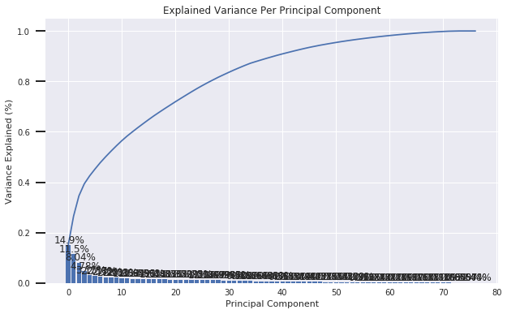

```python
scree_plot(pca) #Variability captured using all components (100%)
```

I don't see an obvious inflection point where there is a sharp reduction in additional explained variance. My instinct is to only use enough principal components to explain somewhere around 80% of the variance. According to Statistics Globe (https://statisticsglobe.com/choose-optimal-number-components-pca), there's something called Kaiser's Rule, where it's advised to keep any principal component whose eigenvalue is 1 or greater. I'll extract the eigenvalues below:

```python
pca.explained_variance_
```

```
array([1.15483540e+01, 8.87637610e+00, 6.19360387e+00, 3.68284089e+00,
       2.43049092e+00, 2.08994225e+00, 1.98081458e+00, 1.79309930e+00,
       1.69783477e+00, 1.62742261e+00, 1.55232369e+00, 1.42703502e+00,
       1.30829820e+00, 1.26972883e+00, 1.22730892e+00, 1.20587821e+00,
       1.16991786e+00, 1.10529694e+00, 1.08217445e+00, 1.05647941e+00,
       1.05115995e+00, 1.02134411e+00, 1.00745477e+00, 9.98726614e-01,
       9.69987479e-01, 9.25354931e-01, 8.85322783e-01, 8.44220914e-01,
       8.29882281e-01, 7.69719343e-01, 7.57265503e-01, 7.38441383e-01,
       6.95955565e-01, 6.80735458e-01, 6.38165980e-01, 5.11234581e-01,
       4.98449647e-01, 4.88890842e-01, 4.71249427e-01, 4.64537407e-01,
       4.34361603e-01, 4.16980196e-01, 4.12144092e-01, 3.97860263e-01,
       3.84924617e-01, 3.69672067e-01, 3.27877174e-01, 3.26590067e-01,
       2.92219049e-01, 2.84632330e-01, 2.69930658e-01, 2.67040708e-01,
       2.44561769e-01, 2.34497844e-01, 2.23353685e-01, 2.07575279e-01,
       2.04647016e-01, 1.97654500e-01, 1.88427720e-01, 1.78952934e-01,
       1.69289719e-01, 1.62033787e-01, 1.54499201e-01, 1.47162927e-01,
       1.39551343e-01, 1.37693223e-01, 1.23939323e-01, 1.05837292e-01,
       1.03448644e-01, 8.52017181e-02, 8.14360175e-02, 7.80890177e-02,
       3.90579852e-02, 3.56600355e-02, 7.31901615e-25, 1.98309445e-26,
       1.88042613e-26])
```

I count 23 principal components whose eigenvalues are greater than 1. I'll try reducing the features to 23:

```
This process took 3.289268233333333 minutes
```

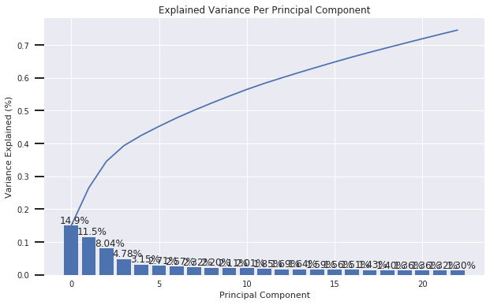

```python
# Re-apply PCA to the data while selecting for number of components to retain.
start_time = time.clock()
pca = PCA(23, random_state=42)
demo_pca = pca.fit_transform(scaled_demo)
scree_plot(pca)
end_time = time.clock()
processing_time = end_time - start_time
print('This process took {} minutes'.format(processing_time/60))
```

Using Kaiser's Rule to reduce the dimension to 23 features, about 75-80% of the variance in the data is captured.

### Discussion 2.2: Perform Dimensionality Reduction

It's kind of challenging to pick the number of features to extract from this dataset because there isn't a small subset of features that would explain the bulk of the variability. The Pareto Principle suggests that we should expect 80% of the variability to be explained by 15-16 features, but that isn't true with this dataset; 15 features, according to the chart above, would explain only about 65% of the variability.

Instead, what I see in the eigenvalues and scree charts above is that about 45% of the variability can be exlained by extracting 5 features, but each feature after that only explains about 1% of the variability. As a result, it's going to take a lot of features to retain any significant variability.

One option is to minimize the time it will take to process the data by reducing the set to the 5 most explanatory features. Another option is to make sure I retain a high amount of variability by choosing to keep 90% of the variability, which will take about 40 features. Another option, which is sort of a middle ground, is to use the Kaiser Rule (cited above) to only keep features whose eigenvalue is greater than 1. For the time being, I am choosing the Kaiser Rule approach, but if I struggle to make an accurate model later on, I might revisit this step.

### Step 2.3: Interpret Principal Components

Now that we have our transformed principal components, it's a nice idea to check out the weight of each variable on the first few components to see if they can be interpreted in some fashion.

As a reminder, each principal component is a unit vector that points in the direction of highest variance (after accounting for the variance captured by earlier principal components). The further a weight is from zero, the more the principal component is in the direction of the corresponding feature. If two features have large weights of the same sign (both positive or both negative), then increases in one tend expect to be associated with increases in the other. To contrast, features with different signs can be expected to show a negative correlation: increases in one variable should result in a decrease in the other.

- To investigate the features, you should map each weight to their corresponding feature name, then sort the features according to weight. The most interesting features for each principal component, then, will be those at the beginning and end of the sorted list. Use the data dictionary document to help you understand these most prominent features, their relationships, and what a positive or negative value on the principal component might indicate.
- You should investigate and interpret feature associations from the first three principal components in this substep. To help facilitate this, you should write a function that you can call at any time to print the sorted list of feature weights, for the *i*-th principal component. This might come in handy in the next step of the project, when you interpret the tendencies of the discovered clusters.

```python
# Map weights for the first principal component to corresponding feature names
# and then print the linked values, sorted by weight.
# HINT: Try defining a function here or in a new cell that you can reuse in the
# other cells.
#pca.components_ #This is a 2-dimensional array: 23 components, each component has 77 entries.
#Each entry is the weight associated with that feature in the original dataset.


#Make a list of the feature names:
features = demo_cleaned.columns.to_list()

def get_sorted_weights(component):
    """
    get_sorted_weights takes a principal component number in your PCA object and prints the 10
    heaviest-weighted features in that principal component (5 most positive and 5 most negative)
    """
    feature_weights = list(zip(features, pca.components_[component])) #link weights to features
    fw_sorted = sorted(feature_weights, key=lambda x: x[1], reverse=True) #sort features by weight
    for i in range(0,5): #print 5 largest weights
        print(fw_sorted[i])
    print()
    for i in range(76, 71, -1):
        print(fw_sorted[i]) #print 5 largest negative weights
get_sorted_weights(0)
```

```
('PLZ8_ANTG3', 0.21545163052693184)
('PLZ8_ANTG4', 0.20906132888091358)
('HH_EINKOMMEN_SCORE', 0.19557135515361315)
('ORTSGR_KLS9', 0.18490765560956077)
('EWDICHTE', 0.18209314796523335)

('MOBI_REGIO', -0.23422391538989654)
('KBA05_ANTG1', -0.21931403657910015)
('PLZ8_ANTG1', -0.2173412616919566)
('FINANZ_MINIMALIST', -0.21480839498073248)
('KBA05_GBZ', -0.2091186992261034)
```

#### Component 1:

- PLZ8_ANTG3: Number of 6-10 family houses in the PLZ8 region
- PLZ8_ANTG4: Number of 10+ family houses in the PLZ8 region
- HH_EINKOMMEN_SCORE: Estimated household net income (decreasing)
- ORTSGR_KLS9: Size of community (population)
- EWDICHTE: Density of households per square kilometer
- MOBI_REGIO: Movement patterns (decreasing)
- KBA05_ANTG1: Number of 1-2 family houses in the microcell
- PLZ8_ANTG1: Number of 1-2 family houses in the PLZ8 region
- FINANZ_MINIMALIST: MINIMALIST: low financial interest (increasing)
- KBA05_GBZ: Number of buildings in the microcell

Interpretation:

Having a large number of 6+-family housing units correlates well with a low estimated household income, large zone population, and dense housing. In other words, inner-city areas with housing instability.

Having little movement correlates highly with having more single/double-family houses in a region, higher spending habits, and more buildings in the area. In other words, settled, wealthier suburbs.

These two feature groups are negatively correlated with each other. In other words, having lots of high-density housing in a region means you'll have fewer single-family homes and thriftier spending habits.

```python
# Map weights for the second principal component to corresponding feature names
# and then print the linked values, sorted by weight.
get_sorted_weights(1)
```

```
('ALTERSKATEGORIE_GROB', 0.254150254950927)
('SEMIO_ERL', 0.22820555252392852)
('FINANZ_VORSORGER', 0.2221659779632272)
('SEMIO_LUST', 0.17503127945737235)
('RETOURTYP_BK_S', 0.1642306484219737)

('SEMIO_REL', -0.2580319463912486)
('SEMIO_PFLICHT', -0.23367763483947862)
('FINANZ_SPARER', -0.22861845311660647)
('SEMIO_TRADV', -0.22655008876497024)
('FINANZ_UNAUFFAELLIGER', -0.22362008533932007)
```

#### Component 2

- ALTERSKATEGORIE_GROB: Estimated age based on given name analysis (increasing)
- SEMIO_ERL: ERL: event-oriented (decreasing affinity)
- FINANZ_VORSORGER: VORSORGER: be prepared (decreasing)
- SEMIO_LUST: LUST: sensual-minded (decreasing affinity)
- RETOURTYP_BK_S: Return type (amount of returns made by shopper) (decreasing)
- SEMIO_REL: REL: religious (decreasing affinity)
- SEMIO_PFLICHT: dutiful (decreasing affinity)
- FINANZ_SPARER: money-saver (decreasing)
- SEMIO_TRADV: traditional-minded (decreasing affinity)
- FINANZ_UNAUFFAELLIGER: inconspicuous (decreasing)

Interpretation:

Some of the correlated features in this component are age, going to events, and returning purchases. In other words, older people are less likely to go to events, get into "preparedness," be sensual, and make shopping returns.

On the opposite end of the component are features like being religious, dutiful, and traditional. In other words, people who are not very religious are also not very dutiful, or traditional, or inconspicuous, or likely to save money.

These two feature groups are negatively correlated with each other, so the older a person is, the more likely they are to be religious, dutiful, etc.

```python
# Map weights for the third principal component to corresponding feature names
# and then print the linked values, sorted by weight.
get_sorted_weights(2)
```

```
('SEMIO_VERT', 0.3486545789094202)
('SEMIO_SOZ', 0.26445893895565564)
('SEMIO_FAM', 0.25286973597778756)
('SEMIO_KULT', 0.23342865666666585)
('FINANZ_MINIMALIST', 0.15862863782606346)

('ANREDE_KZ', -0.36821788154744545)
('SEMIO_KAEM', -0.33792281197923224)
('SEMIO_DOM', -0.3121930499963506)
('SEMIO_KRIT', -0.2703409223042888)
('SEMIO_RAT', -0.21629421785191041)
```

#### Component 3

- SEMIO_VERT: dreamful (decreasing affinity)
- SEMIO_SOZ: socially-minded (decreasing...)
- SEMIO_FAM: family-minded
- SEMIO_KULT: cultural-minded
- FINANZ_MINIMALIST: low financial interest (decreasing)
- ANREDE_KZ: gender (1: male; 2: female)
- SEMIO_KAEM: combative attitude (decreasing...)
- SEMIO_DOM: dominant-minded
- SEMIO_KRIT: critical-minded
- SEMIO_RAT: rational

Interpretation:

Most of the associated features in this vector have to do with personality. On one end are people who are 'dreamful,' social, family, and cultural-minded, and are financial minimalists. On the other end of the spectrum are people who are male, combative, dominant, critical, and rational. These two sides are inversely related, so people who are more social and culturally-minded will be less combative and dominant.

### Discussion 2.3: Interpret Principal Components

The first principal component extracted information that primarily regarded household size and income. The second component was a bit of a grab bag, mixing age, likelihood of returning purchases, and a few personality types like religiosity. The third component extracted information regarding personality types.

We can interpret positive and negative values of different feature weights to tell us how features correlate to each other. For example, in the first component, we saw that the number of 6+ family homes and 10+ family homes both had positive weights, meaning that as the number of 6+ family homes increases, the number of 10+ family homes will also likely increase. Conversely, the number of single-family homes had a negative weight, so as the number of single-family homes increases, the amount of high-density housing will likely decrease.

## Step 3: Clustering

### Step 3.1: Apply Clustering to General Population

You've assessed and cleaned the demographics data, then scaled and transformed them. Now, it's time to see how the data clusters in the principal components space. In this substep, you will apply k-means clustering to the dataset and use the average within-cluster distances from each point to their assigned cluster's centroid to decide on a number of clusters to keep.

- Use sklearn's KMeans class to perform k-means clustering on the PCA-transformed data.
- Then, compute the average difference from each point to its assigned cluster's center. **Hint**: The KMeans object's `.score()` method might be useful here, but note that in sklearn, scores tend to be defined so that larger is better. Try applying it to a small, toy dataset, or use an internet search to help your understanding.
- Perform the above two steps for a number of different cluster counts. You can then see how the average distance decreases with an increasing number of clusters. However, each additional cluster provides a smaller net benefit. Use this fact to select a final number of clusters in which to group the data. **Warning**: because of the large size of the dataset, it can take a long time for the algorithm to resolve. The more clusters to fit, the longer the algorithm will take. You should test for cluster counts through at least 10 clusters to get the full picture, but you shouldn't need to test for a number of clusters above about 30.
- Once you've selected a final number of clusters to use, re-fit a KMeans instance to perform the clustering operation. Make sure that you also obtain the cluster assignments for the general demographics data, since you'll be using them in the final Step 3.3.

```python
# Over a number of different cluster counts...
# Note: comment this out during development phase because it takes 1/2 hour to run.
# Note 2: I'm using inertia_ rather than .score()

inertia = []
clusters = [2, 5, 10, 15, 20]
start_time = time.clock()
for i in clusters:
    # run k-means clustering on the data and...
    kmeans = KMeans(n_clusters=i, random_state=42)
    model = kmeans.fit(demo_pca)
    # compute the average within-cluster distances.
    inertia.append(model.inertia_)
end_time = time.clock()
processing_time = end_time - start_time
print('This process took {} minutes'.format(processing_time/60))
```

```
This process took 23.77899228333333 minutes
```

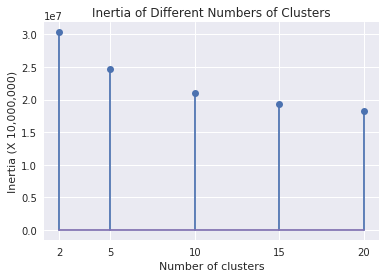

```python
# Investigate the change in within-cluster distance across number of clusters.
# HINT: Use matplotlib's plot function to visualize this relationship.
# plot
fig, ax = plt.subplots()
ax.stem(clusters, inertia)
ax.set(xticks = clusters)
plt.xlabel('Number of clusters')
plt.ylabel('Inertia (X 10,000,000)')
plt.title('Inertia of Different Numbers of Clusters')
plt.show()
```

```python
# Re-fit the k-means model with the selected number of clusters and...
start_time = time.clock()
kmeans = KMeans(n_clusters=15, random_state=42)
model = kmeans.fit(demo_pca)
end_time = time.clock()
processing_time = end_time - start_time
print('This process took {} minutes'.format(processing_time/60))
```

```
This process took 6.733145683333332 minutes
```

```python
#obtain cluster predictions for the general population demographics data.
gen_prediction = model.predict(demo_pca)
```

### Discussion 3.1: Apply Clustering to General Population

I tried a few different number of clusters, and I found that there was almost no improvement in inertia for using more than 15 clusters (inertia being the term for the sum of the squares of the distance of each point to the center of the cluster). Actually, 15 clusters didn't offer a lot of improvement over 10, but I decided to use 15 clusters in order to minimize inertia. It takes about 8 minutes to fit the data to a model with 15 clusters, so I might reconsider this decision when it starts taking an hour to run this notebook from beginning to end.

### Step 3.2: Apply All Steps to the Customer Data

Now that you have clusters and cluster centers for the general population, it's time to see how the customer data maps on to those clusters. Take care to not confuse this for re-fitting all of the models to the customer data. Instead, you're going to use the fits from the general population to clean, transform, and cluster the customer data. In the last step of the project, you will interpret how the general population fits apply to the customer data.

- Don't forget when loading in the customers data, that it is semicolon (`;`) delimited.
- Apply the same feature wrangling, selection, and engineering steps to the customer demographics using the `clean_data()` function you created earlier. (You can assume that the customer demographics data has similar meaning behind missing data patterns as the general demographics data.)
- Use the sklearn objects from the general demographics data, and apply their transformations to the customers data. That is, you should not be using a `.fit()` or `.fit_transform()` method to re-fit the old objects, nor should you be creating new sklearn objects! Carry the data through the feature scaling, PCA, and clustering steps, obtaining cluster assignments for all of the data in the customer demographics data.

```python
# Load in the customer demographics data.
customers = pd.read_csv('Udacity_CUSTOMERS_Subset.csv', sep=';')
```

```python
# Apply preprocessing, feature transformation, and clustering from the general
# demographics onto the customer data, obtaining cluster predictions for the
# customer demographics data.
cust_start_time = time.clock()
customers_cleaned = clean_data(customers) #Clean
customers_scaled = scaler.transform(customers_cleaned) #Scale
customers_pca = pca.transform(customers_scaled) #apply PCA
customers_preds = model.predict(customers_pca) #Get predictions. This assigns a cluster to each datapoint
cust_end_time = time.clock()
print('This process took {} minutes'.format((cust_end_time - cust_start_time)/60))
```

[output not shown]

```
This process took 0.1837124000000055 minutes
```

### Step 3.3: Compare Customer Data to Demographics Data

At this point, you have clustered data based on demographics of the general population of Germany, and seen how the customer data for a mail-order sales company maps onto those demographic clusters. In this final substep, you will compare the two cluster distributions to see where the strongest customer base for the company is.

Consider the proportion of persons in each cluster for the general population, and the proportions for the customers. If we think the company's customer base to be universal, then the cluster assignment proportions should be fairly similar between the two. If there are only particular segments of the population that are interested in the company's products, then we should see a mismatch from one to the other. If there is a higher proportion of persons in a cluster for the customer data compared to the general population (e.g. 5% of persons are assigned to a cluster for the general population, but 15% of the customer data is closest to that cluster's centroid) then that suggests the people in that cluster to be a target audience for the company. On the other hand, the proportion of the data in a cluster being larger in the general population than the customer data (e.g. only 2% of customers closest to a population centroid that captures 6% of the data) suggests that group of persons to be outside of the target demographics.

Take a look at the following points in this step:

- Compute the proportion of data points in each cluster for the general population and the customer data. Visualizations will be useful here: both for the individual dataset proportions, but also to visualize the ratios in cluster representation between groups. Seaborn's [`countplot()`](https://seaborn.pydata.org/generated/seaborn.countplot.html) or [`barplot()`](https://seaborn.pydata.org/generated/seaborn.barplot.html) function could be handy.
  - Recall the analysis you performed in step 1.1.3 of the project, where you separated out certain data points from the dataset if they had more than a specified threshold of missing values. If you found that this group was qualitatively different from the main bulk of the data, you should treat this as an additional data cluster in this analysis. Make sure that you account for the number of data points in this subset, for both the general population and customer datasets, when making your computations!
- Which cluster or clusters are overrepresented in the customer dataset compared to the general population? Select at least one such cluster and infer what kind of people might be represented by that cluster. Use the principal component interpretations from step 2.3 or look at additional components to help you make this inference. Alternatively, you can use the `.inverse_transform()` method of the PCA and StandardScaler objects to transform centroids back to the original data space and interpret the retrieved values directly.
- Perform a similar investigation for the underrepresented clusters. Which cluster or clusters are underrepresented in the customer dataset compared to the general population, and what kinds of people are typified by these clusters?

```python
# Compare the proportion of data in each cluster for the customer data to the
# proportion of data in each cluster for the general population.

#Get proportion of data in each cluster:
#gen_prediction are the general population predictions
#customers_preds are the customer population predictions
cust_pred_proportions = np.bincount(customers_preds)/sum(np.bincount(customers_preds))
demo_pred_proportions = np.bincount(gen_prediction)/sum(np.bincount(gen_prediction))
```

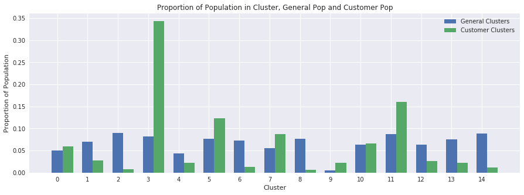

```python
#Bar graphs of proportion of data in each cluster:
index = np.arange(15)
bar_width = 0.35

fig, ax = plt.subplots()
fig.set_figheight(5)
fig.set_figwidth(15)
general = ax.bar(index, demo_pred_proportions, bar_width,
                label="General Clusters")

customer = ax.bar(index+bar_width, cust_pred_proportions,
                 bar_width, label="Customer Clusters")

ax.set_xlabel('Cluster')
ax.set_ylabel('Proportion of Population')
ax.set_title('Proportion of Population in Cluster, General Pop and Customer Pop')
ax.set_xticks(index)
ax.legend()
plt.show()
```

### Overrepresented features in the customer dataset:

Overrepresented clusters in the customer dataset: 3, 5, and 11. 3 is especially overrepresented, so I will focus on that one.  
note: I relied on Rajat's very helpful answer to this question (https://knowledge.udacity.com/questions/906309) for inspiration about how to proceed with this segment.

```python
#Transform the cluster to its pre-scaled state
interesting_custs = scaler.inverse_transform(np.dot(customers_pca, pca.components_))[np.where(customers_preds==3)]
#Change the cluster to its own dataframe
interesting_custs = pd.DataFrame(interesting_custs, columns=customers_cleaned.columns)
#Verify reverse transformation visually
interesting_custs.head()
```

|  | ALTERSKATEGORIE_GROB | ANREDE_KZ | FINANZ_MINIMALIST | FINANZ_SPARER | FINANZ_VORSORGER | FINANZ_ANLEGER | FINANZ_UNAUFFAELLIGER | FINANZ_HAUSBAUER | GREEN_AVANTGARDE | HEALTH_TYP | RETOURTYP_BK_S | SEMIO_SOZ | SEMIO_FAM | SEMIO_REL | SEMIO_MAT | SEMIO_VERT | SEMIO_LUST | SEMIO_ERL | SEMIO_KULT | SEMIO_RAT | SEMIO_KRIT | SEMIO_DOM | SEMIO_KAEM | SEMIO_PFLICHT | SEMIO_TRADV | SOHO_KZ | VERS_TYP | ANZ_PERSONEN | ANZ_TITEL | … |
| --- | --- | --- | --- | --- | --- | --- | --- | --- | --- | --- | --- | --- | --- | --- | --- | --- | --- | --- | --- | --- | --- | --- | --- | --- | --- | --- | --- | --- | --- | --- |
| 0 | 4.135833 | 0.876664 | 4.972897 | 1.068651 | 4.860900 | 0.722883 | 2.145927 | 2.224420 | 1.040042 | 1.176514 | 4.230980 | 5.739226 | 5.001972 | 3.013522 | 4.429347 | 7.418683 | 7.128238 | 4.416473 | 4.432544 | 1.624455 | 2.312931 | 1.864727 | 1.277491 | 1.682820 | 2.254503 | -0.021628 | 0.923028 | 1.933549 | 0.013331 | … |
| 1 | 3.185089 | 1.034202 | 4.365054 | 1.623940 | 4.469626 | 1.114037 | 2.239625 | 2.676518 | 0.955520 | 2.855747 | 3.872036 | 5.655673 | 4.931169 | 3.202868 | 2.385831 | 5.929415 | 4.680097 | 3.997905 | 4.356655 | 2.006207 | 3.904216 | 3.952867 | 2.592595 | 2.937296 | 2.855219 | 0.042124 | 2.358747 | 1.840765 | 0.006873 | … |
| 2 | 3.589833 | 1.085832 | 5.037945 | 1.158485 | 4.824683 | 1.405219 | 1.982822 | 2.094706 | 0.950015 | 1.763791 | 3.974743 | 5.067258 | 4.566207 | 3.401369 | 3.437804 | 6.282245 | 5.866987 | 4.437664 | 4.501501 | 2.349590 | 3.065859 | 2.836739 | 2.249247 | 2.764289 | 2.699832 | -0.032370 | 1.341611 | 2.222897 | 0.006127 | … |
| 3 | 3.984329 | 0.895921 | 5.225867 | 0.891507 | 4.633065 | 0.440870 | 1.781518 | 2.288702 | 1.089000 | 1.247187 | 4.329904 | 5.785457 | 5.013045 | 3.130396 | 4.795428 | 7.334435 | 6.834518 | 4.278920 | 4.560102 | 1.883976 | 2.392067 | 2.315099 | 1.533678 | 1.842594 | 2.572211 | 0.028712 | 1.003392 | 1.890409 | 0.009818 | … |
| 4 | 2.991804 | 1.023077 | 5.077224 | 2.185444 | 3.509829 | 2.089366 | 2.551175 | 0.917237 | 1.066160 | 2.938168 | 3.550783 | 5.987271 | 4.537436 | 3.559776 | 2.049137 | 6.091151 | 4.526889 | 3.941874 | 5.050840 | 2.227062 | 3.488235 | 4.019458 | 3.061971 | 3.436145 | 2.689349 | 0.028642 | 2.118731 | 3.141756 | 0.026912 | … |

These values all have decimal values, which won't work well with a hist function or bar graph. I'll round them:

```python
#rounding and changing values to integers:
interesting_custs = interesting_custs.round(0).astype(int)
#Verify operation:
interesting_custs.head()
```

|  | ALTERSKATEGORIE_GROB | ANREDE_KZ | FINANZ_MINIMALIST | FINANZ_SPARER | FINANZ_VORSORGER | FINANZ_ANLEGER | FINANZ_UNAUFFAELLIGER | FINANZ_HAUSBAUER | GREEN_AVANTGARDE | HEALTH_TYP | RETOURTYP_BK_S | SEMIO_SOZ | SEMIO_FAM | SEMIO_REL | SEMIO_MAT | SEMIO_VERT | SEMIO_LUST | SEMIO_ERL | SEMIO_KULT | SEMIO_RAT | SEMIO_KRIT | SEMIO_DOM | SEMIO_KAEM | SEMIO_PFLICHT | SEMIO_TRADV | SOHO_KZ | VERS_TYP | ANZ_PERSONEN | ANZ_TITEL | … |
| --- | --- | --- | --- | --- | --- | --- | --- | --- | --- | --- | --- | --- | --- | --- | --- | --- | --- | --- | --- | --- | --- | --- | --- | --- | --- | --- | --- | --- | --- | --- |
| 0 | 4 | 1 | 5 | 1 | 5 | 1 | 2 | 2 | 1 | 1 | 4 | 6 | 5 | 3 | 4 | 7 | 7 | 4 | 4 | 2 | 2 | 2 | 1 | 2 | 2 | 0 | 1 | 2 | 0 | … |
| 1 | 3 | 1 | 4 | 2 | 4 | 1 | 2 | 3 | 1 | 3 | 4 | 6 | 5 | 3 | 2 | 6 | 5 | 4 | 4 | 2 | 4 | 4 | 3 | 3 | 3 | 0 | 2 | 2 | 0 | … |
| 2 | 4 | 1 | 5 | 1 | 5 | 1 | 2 | 2 | 1 | 2 | 4 | 5 | 5 | 3 | 3 | 6 | 6 | 4 | 5 | 2 | 3 | 3 | 2 | 3 | 3 | 0 | 1 | 2 | 0 | … |
| 3 | 4 | 1 | 5 | 1 | 5 | 0 | 2 | 2 | 1 | 1 | 4 | 6 | 5 | 3 | 5 | 7 | 7 | 4 | 5 | 2 | 2 | 2 | 2 | 2 | 3 | 0 | 1 | 2 | 0 | … |
| 4 | 3 | 1 | 5 | 2 | 4 | 2 | 3 | 1 | 1 | 3 | 4 | 6 | 5 | 4 | 2 | 6 | 5 | 4 | 5 | 2 | 3 | 4 | 3 | 3 | 3 | 0 | 2 | 3 | 0 | … |

Now I'll compare histograms of the most important features (according to the PCA analysis) in customer cluster 3 to histograms of the general population. Those features are:

- PLZ8_ANTG3: Number of 6-10 family houses in the PLZ8 region
- PLZ8_ANTG4: Number of 10+ family houses in the PLZ8 region
- HH_EINKOMMEN_SCORE: Estimated household net income (decreasing)
- MOBI_REGIO: Movement patterns (decreasing)
- KBA05_ANTG1: Number of 1-2 family houses in the microcell
- PLZ8_ANTG1: Number of 1-2 family houses in the PLZ8 region  
  I'm comparing the general population to the cluster instead of just analyzing the cluster because I will feel more confident that I'm on the right track if I see that there is a significant difference between the two for each feature I analyze.

```python
def compare_cluster_plot(feature):
    """
    compare_cluster_plot takes the name of a feature (as a string) and creates two bar plots side
    by side. The first plot is the distribution of values of that feature in the general population,
    and the second plot is the distribution of values of that feature in the specific customer
    cluster we're looking at (cluster 3, in this case).

    This function creates two separate bar plots instead of one bar plot with different colored bars
    side-by-side because some values used in the general population are not used at all in the
    cluster, so it would be very complicated to plot both populations using the same x-axis.
    """
    #Each bar plot gets its own index. The index is calculated by finding the largest value possible
    #and then adding what *would* be the next value on to that (np.arange uses half-open intervals,
    #so the last possible value won't be included unless we add an additional value beyond the max)
    index1 = np.arange(demo_cleaned[feature].unique().max()
                     + demo_cleaned[feature].max()/len(demo_cleaned[feature])).astype(int)

    index2 = np.arange(interesting_custs[feature].unique().max()
                     + interesting_custs[feature].max()/len(interesting_custs[feature])).astype(int)

    bar_width = 0.35

    #Create the bar graph for the general population
    general_props = np.bincount(demo_cleaned[feature])/len(demo_cleaned[feature])
    plt.subplot(1,2,1)
    plt.bar(x = index1, height = general_props, width = bar_width)
    plt.title('General Population')
    plt.xlabel(feature)
    plt.ylabel('Proportion')

    #Create the bar graph for differentiated customer cluster
    cust_props = np.bincount(interesting_custs[feature])/len(interesting_custs[feature])
    plt.subplot(1,2,2)
    plt.bar(x = index2, height = cust_props,
                      width = bar_width, label="Customer Population")
    plt.title('Cluster 3 Population')
    plt.xlabel(feature)
    plt.ylabel('Proportion')
    plt.tight_layout()
```

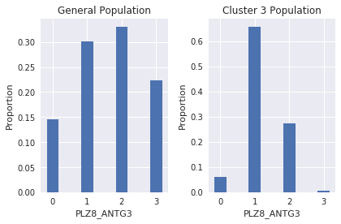

```python
compare_cluster_plot('PLZ8_ANTG3')
```

PLZ8_ANTG3 refers to the number of 6-10-family-houses in the region, with 0 being "none" and 3 being a "high share." In the general population, we see that the spread of this feature is more even. However, in cluster 3 of the customer population, we can see that the density of 6-10 family homes is low-to-average, but primarily low.

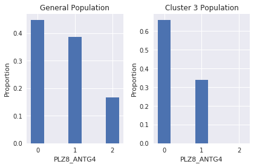

```python
compare_cluster_plot('PLZ8_ANTG4')
```

The difference here in PLZ8_ANTG4 is less pronounced. PLZ8_ANTG4 refers to the number of 10+ family houses in a region. The population of Cluster 3 customers shows that there are fewer of these types of houses among customers.

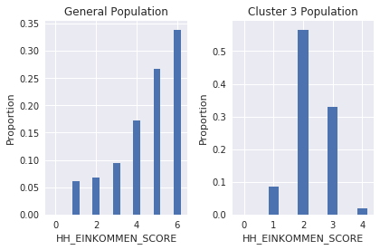

```python
compare_cluster_plot('HH_EINKOMMEN_SCORE')
```

HH_EINKOMMEN_SCORE refers to the household net income, with 0 being unknown, 1 being high, and 6 being very low. The household income of the general population is primarily on the low end, while the household population of customers is "very high" to "high" (codes 2 and 3, respectively).

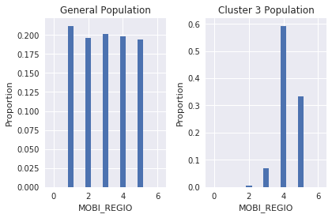

```python
compare_cluster_plot('MOBI_REGIO')
```

MOBI_REGIO refers to movement patterns, with 1 showing a lot of movement and 6 showing no movement. The general population is spread out evenly regarding this feature, while the customer population shows low to very low movement (codes 4 and 5, respectively).

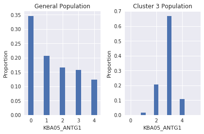

```python
compare_cluster_plot('KBA05_ANTG1')
```

KBA05_ANTG1 refers to the number of 1-2 family houses in the microcell, with 0 being 'none' and 4 being a 'very high share.' The general population predominantly has few 1-2 family houses, while the regions with customers mostly have a high share of 1-2 family houses.

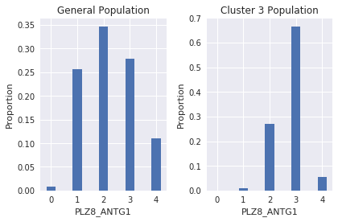

```python
compare_cluster_plot('PLZ8_ANTG1')
```

PLZ8_ANTG1 is basically the same thing as KBA05_ANTG1; this shows a higher share of 1-2 family homes in the PLZ8 macrocell region compared to the general population.

```python
# What kinds of people are part of a cluster that is overrepresented in the
# customer data compared to the general population?
```

The kinds of people who are overrepresented in the customer data are upper-middle-class-to-upper-class. They live in regions with less dense housing and more 1-2 family houses. They have higher household incomes and more housing stability, as shown by less overall movement.  
Next, I'll look at underrepresented features in the customer dataset:

### Underrepresented Features in the Customer Dataset

Clusters 2, 6, 8, and 12-14 are underrepresented by customers, with 2 showing an especially pronounced difference. I'll look at the same features as above, but focus on cluster 2.

```python
#Transform the cluster to its pre-scaled state
interesting_custs = scaler.inverse_transform(np.dot(customers_pca, pca.components_))[np.where(customers_preds==2)]
#Change the cluster to its own dataframe
interesting_custs = pd.DataFrame(interesting_custs, columns=customers_cleaned.columns)
#rounding and changing values to integers:
interesting_custs = interesting_custs.round(0).astype(int)
```

```python
#counting the number of -1 values in KBA05_ANTG1 prior to changing them to 0
interesting_custs[interesting_custs['KBA05_ANTG1'] == -1].KBA05_ANTG1.sum()
```

```
-10
```

```python
#Somehow, some 10 -1s crept back into KBA05_ANTG1. I'm changing them to their closest value: 0
interesting_custs['KBA05_ANTG1'] = \
interesting_custs['KBA05_ANTG1'].apply(lambda x: 0 if (x == -1) else x)
#Verify operation:
interesting_custs.head()
```

|  | ALTERSKATEGORIE_GROB | ANREDE_KZ | FINANZ_MINIMALIST | FINANZ_SPARER | FINANZ_VORSORGER | FINANZ_ANLEGER | FINANZ_UNAUFFAELLIGER | FINANZ_HAUSBAUER | GREEN_AVANTGARDE | HEALTH_TYP | RETOURTYP_BK_S | SEMIO_SOZ | SEMIO_FAM | SEMIO_REL | SEMIO_MAT | SEMIO_VERT | SEMIO_LUST | SEMIO_ERL | SEMIO_KULT | SEMIO_RAT | SEMIO_KRIT | SEMIO_DOM | SEMIO_KAEM | SEMIO_PFLICHT | SEMIO_TRADV | SOHO_KZ | VERS_TYP | ANZ_PERSONEN | ANZ_TITEL | … |
| --- | --- | --- | --- | --- | --- | --- | --- | --- | --- | --- | --- | --- | --- | --- | --- | --- | --- | --- | --- | --- | --- | --- | --- | --- | --- | --- | --- | --- | --- | --- |
| 0 | 2 | 2 | 2 | 3 | 3 | 3 | 3 | 2 | 0 | 3 | 3 | 3 | 4 | 4 | 6 | 3 | 4 | 5 | 3 | 6 | 6 | 7 | 6 | 5 | 5 | 0 | 1 | 1 | 0 | … |
| 1 | 2 | 2 | 3 | 1 | 5 | 1 | 1 | 5 | 0 | 3 | 5 | 3 | 4 | 5 | 5 | 2 | 2 | 4 | 5 | 6 | 6 | 7 | 6 | 7 | 6 | 0 | 2 | 1 | 0 | … |
| 2 | 1 | 2 | 2 | 2 | 4 | 3 | 1 | 5 | 0 | 3 | 4 | 4 | 5 | 6 | 4 | 3 | 2 | 3 | 5 | 6 | 4 | 6 | 5 | 7 | 6 | 0 | 2 | 4 | 0 | … |
| 3 | 1 | 2 | 1 | 4 | 2 | 4 | 4 | 5 | 0 | 3 | 2 | 4 | 4 | 5 | 4 | 2 | 2 | 4 | 3 | 6 | 6 | 7 | 6 | 6 | 6 | 0 | 2 | 3 | 0 | … |
| 4 | 2 | 2 | 1 | 4 | 2 | 4 | 4 | 4 | 0 | 1 | 2 | 2 | 3 | 5 | 6 | 2 | 4 | 5 | 3 | 7 | 5 | 7 | 7 | 6 | 6 | 0 | 1 | 2 | 0 | … |

[figure not shown]

```python
compare_cluster_plot('PLZ8_ANTG3')
```

Underrepresented: a high share of 6-10-family houses.

[figure not shown]

```python
compare_cluster_plot('PLZ8_ANTG4')
```

Underrepresented: a high share of 10+ family houses.

[figure not shown]

```python
compare_cluster_plot('HH_EINKOMMEN_SCORE')
```

Underrepresented: low-income households.

[figure not shown]

```python
compare_cluster_plot('MOBI_REGIO')
```

Underrepresented: high movement.

[figure not shown]

```python
compare_cluster_plot('KBA05_ANTG1')
```

Underrepresented: a lack of 1-2 family houses.

[figure not shown]

```python
compare_cluster_plot('PLZ8_ANTG1')
```

Underrepresented: a lack of 1-2 family houses.

```python
# What kinds of people are part of a cluster that is underrepresented in the
# customer data compared to the general population?
```

The cluster of customers who are underrepresented in the data are people with low income, more movement, and who live among high-density housing.

### Discussion 3.3: Compare Customer Data to Demographics Data

By comparing these features, I found that customers are more affluent than the general population. They live in areas with less dense housing (predominantly 1-2 family houses), and are more settled than the general population. On the flip side, people with low income, or who live in denser neighborhoods (6+ family houses) are not as likely to be customers.

> Congratulations on making it this far in the project! Before you finish, make sure to check through the entire notebook from top to bottom to make sure that your analysis follows a logical flow and all of your findings are documented in **Discussion** cells. Once you've checked over all of your work, you should export the notebook as an HTML document to submit for evaluation. You can do this from the menu, navigating to **File -> Download as -> HTML (.html)**. You will submit both that document and this notebook for your project submission.